# Mini-curso Noções básicas do R

Sollano Rabelo Braga

Novembro, 2017

# 0) Links úteis

Link para baixar a versão mais atualizada do R (Mantenha o R sempre atualizado):

http://cran.fiocruz.br/bin/windows/base/

Link para baixar a versão mais atualizada do RStudio: https://www.rstudio.com/products/rstudio/download/

Curso online gratuito disponibilizado pelo Prof. Eric Gorgens: https://eliademy.com/catalog/programac-o-cientifica-no-r.html

Lista do youtube com videos de introdução ao R, criados pelo Prof. Eric Gorgens: https://www.youtube.com/playlist?list=PLLCIDTaS6A7C4Ig6gf4d66hvyvl5e3zyy

Stack Overflow: Melhor lugar para se tirar dúvidas sobre o R. Ele tem versões em português e inglês, sendo que a em inglês é bem mais completa:

http://stackoverflow.com/questions/tagged/r (ingles)

http://pt.stackoverflow.com/questions/tagged/r (portugues)

R-Bloggers: Blog sobre R: Tutoriais, notícias sobre pacotes, discussões, etc:

https://www.r-bloggers.com/

Links com pdfs disponibilizados pelo pessoal do RStudio. Eles cobrem vários topicos, desde o R básico ao avançado:

https://www.rstudio.com/resources/cheatsheets/

# 1) Criar um projeto e uma área de trabalho

Quando se define a área de trabalho, pode-se trabalhar de forma mais direta podendo-se chamar objetos a partir daquele local diretamente.

Para isso existem duas formas:

Por linha de comando, ou utilizando a interface do RStudio.

Com a interface do RStudio, os trabalhos são separados em projetos, que preservam todas as informações de cada trabalho feito separadamente.

O projeto pode ser criado indo-se em file -> New Project ou no canto superior direito, so símbolo do RStudio

Carregando-se o projeto, ele irá carregar automaticamente a área de trabalho deste projeto

Utilizando linhas de comando pode-se apenas definir o diretório de trabalho, com o comando setwd. Este método era utilizado antes da IDE RStudio ser criada, tendo caído em desuso ultimamente.

# 2) Operadores e comandos úteis

Operadores são semelhantes a funções, e nos permitem fazer as operações mais básicas no R. Podem ser divididos entre operadores matemáticos e lógicos:

utilize # para criar comentários

Operadores matemáticos:

“+” soma;

“-” subtração;

“/” divisão;

“*" multiplicação;

“%*%" multiplicação de matrizes;

“^” exponenciação ;

“~” usado em fórmulas de modelos (y ~ x);

Operadores lógicos:

“==” igualdade (não confundir com =, o operador de atribuição);

“!=” diferente de;

“!x” diferente de x;

“x & y” x E y;

“x | y” x OU y;

“>” maior que;

“=>” maior ou igual que;

“<” menor que;

“<=” menor ou igual que;

1:5 %in% 1:20; 1:5 existe dentro de 1:20?;

Operadores lógicos serão melhor exemplificados no tópico 8.

A seguir serão mostrados alguns comandos úteis. Esta lista pode ser utilizada ao longo do curso sempre que necessário:

Interrogação na frente de um comando ou termo abre o menu de ajuda:

```r
?summary
```

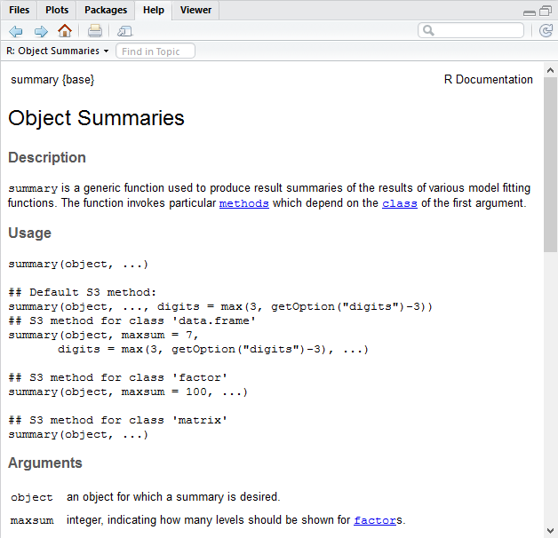

documentação de ajuda da função summary

Dimensão dos dados:

```r
dim(iris)
```

```
## [1] 150   5
```

Número de linhas dos dados:

```r
nrow(iris)
```

```
## [1] 150
```

Número de colunas dos dados:

```r
ncol(iris)
```

```
## [1] 5
```

Comprimento dos dados:

```r
length(iris)
```

```
## [1] 5
```

6 primeiras linhas dos dados:

```r
head(iris)
```

| Sepal.Length | Sepal.Width | Petal.Length | Petal.Width | Species |
| --- | --- | --- | --- | --- |
| 5.1 | 3.5 | 1.4 | 0.2 | setosa |
| 4.9 | 3.0 | 1.4 | 0.2 | setosa |
| 4.7 | 3.2 | 1.3 | 0.2 | setosa |
| 4.6 | 3.1 | 1.5 | 0.2 | setosa |
| 5.0 | 3.6 | 1.4 | 0.2 | setosa |
| 5.4 | 3.9 | 1.7 | 0.4 | setosa |

6 ultimas linhas dos dados:

```r
tail(iris)
```

|  | Sepal.Length | Sepal.Width | Petal.Length | Petal.Width | Species |
| --- | --- | --- | --- | --- | --- |
| 145 | 6.7 | 3.3 | 5.7 | 2.5 | virginica |
| 146 | 6.7 | 3.0 | 5.2 | 2.3 | virginica |
| 147 | 6.3 | 2.5 | 5.0 | 1.9 | virginica |
| 148 | 6.5 | 3.0 | 5.2 | 2.0 | virginica |
| 149 | 6.2 | 3.4 | 5.4 | 2.3 | virginica |
| 150 | 5.9 | 3.0 | 5.1 | 1.8 | virginica |

Nomes das variáveis:

```r
names(iris)
```

```
## [1] "Sepal.Length" "Sepal.Width"  "Petal.Length" "Petal.Width"
## [5] "Species"
```

Informações estruturais sobre os dados:

```r
str(iris)
```

```
## 'data.frame':    150 obs. of  5 variables:
##  $ Sepal.Length: num  5.1 4.9 4.7 4.6 5 5.4 4.6 5 4.4 4.9 ...
##  $ Sepal.Width : num  3.5 3 3.2 3.1 3.6 3.9 3.4 3.4 2.9 3.1 ...
##  $ Petal.Length: num  1.4 1.4 1.3 1.5 1.4 1.7 1.4 1.5 1.4 1.5 ...
##  $ Petal.Width : num  0.2 0.2 0.2 0.2 0.2 0.4 0.3 0.2 0.2 0.1 ...
##  $ Species     : Factor w/ 3 levels "setosa","versicolor",..: 1 1 1 1 1 1 1 1 1 1 ...
```

Classe das variáveis:

```r
class(iris)
```

```
## [1] "data.frame"
```

Concatenar; Une números, caracteres em um vetor:

```r
c(1,3,"quatro")
```

```
## [1] "1"      "3"      "quatro"
```

Compara dois dataframes e diz se eles são idênticos ou não:

```r
all.equal(iris,iris)
```

```
## [1] TRUE
```

remove todos os NAs:

```r
# na.omit(iris)
```

Substitui NA por 0:

```r
iris[is.na(iris)] <- 0
```

Substitui 0 por NA:

```r
iris[iris==0] <- NA
```

Tabela de frequência absoluta:

```r
table(iris$DESCCATEGORIA)
```

```
## < table of extent 0 >
```

Tabela de frequência relativa:

```r
table(iris$DESCCATEGORIA)/nrow(iris) * 100
```

```
## numeric(0)
```

Apaga variável:

```r
iris$Idade <- NULL
```

apaga objeto:

```r
# rm(x)
```

Limpar a área de trabalho:

```r
# rm(list = ls())
```

Listar todos os objetos:

```r
#ls()
```

# 3) Criação de objetos e atribuição de valores

Objetos tem valores associados a eles quando se utiliza <- ou =. No exemplo a seguir, um objeto x e criado, que tem o valor de 10:

```r
x <- 10
x = 10

x
```

```
## [1] 10
```

Para se deletar um objeto, utiliza-se a função rm():

```r
rm(x)
```

Pode-se atribuir um conjunto de números, utilizando c(), ou seq():

```r
y <- c(1,2,3,4,5,6,7,8)
z <- seq(from = 1, to = 8, by = 1)
z <- 1:8
```

R e sensível a maiúsculas e minúsculas (Case sensitive). então y é diferente de Y:

```r
y
```

```
## [1] 1 2 3 4 5 6 7 8
```

```r
#Y
```

Nomes de objetos podem conter números, mas não podem começar com números:

```r
x1 <- 35
```

# 4) Classes de objetos (Class)

Dados carregados e salvos no ambiente R são chamados de objetos. pode-se criar objetos no R com o comando ->, <-, ou =

```r
x <- 10
10 -> x
x = 10
```

Qual método utilizado para salvar objetos fica a critério do usuário entretanto, não e recomendado o uso do =, pois o mesmo símbolo e utilizado com outros significados, criando um código confuso.

neste curso será utilizado <- objetos podem pertencer a diferentes classes:

## 4.1) Numeric (Números decimais)

valores decimais são chamados de numéricos no R. Este e o tipo computacional de dadospadrão no R, ou seja, quando se cria um dado numérico, ele automaticamente possui classe numeric.

Pode-se verificar isto com a função class():

```r
x <- 3
x
```

```
## [1] 3
```

```r
class(x)
```

```
## [1] "numeric"
```

pode-se verificar se x realmente e numeric com a função is.numeric()

```r
is.numeric(x)
```

```
## [1] TRUE
```

## 4.2) Integer (Números inteiros)

para se criar um objeto de classe integer, utiliza-se as.integer(), já que porpadrão o R cria objetos numéricos de classe numeric:

```r
x <- as.integer(3)
x
```

```
## [1] 3
```

```r
class(x)
```

```
## [1] "integer"
```

## 4.3) Logical (lógicos)

Valores lógicos são utilizados para comparações, e são gerados toda vez que se compara objetos no R utilizando operadores como maior que (>), menor que (<), ou igual a (==).

Por exemplo, digamos que se tenha objetos chamados x e y, com valores de 1 e 2, respectivamente: Primeiro cria-se objetos para exemplo:

```r
x <- 1; y <- 2
```

x e maior do que y?

```r
x > y
```

```
## [1] FALSE
```

```r
class(x > y)
```

```
## [1] "logical"
```

Se a comparação for feita com um vetor maior, o resultado são vários elementos lógicos:

```r
5 > c(1:7)
```

```
## [1]  TRUE  TRUE  TRUE  TRUE FALSE FALSE FALSE
```

Outro operador utilizado e o %in%, que indica se um conjunto de dados existe dentro de outro conjunto:

```r
4:6 %in% 1:10
```

```
## [1] TRUE TRUE TRUE
```

## 4.4) Character (Caracteres)

Character representa valores string no R. Palavras, frases, etc. Mesmo um dado de classe pode se tornar um valor string. Isto pode ocorrer involuntariamente, gerando erros, pois não e possível realizar calculos com dados de classe Character. Existem vários métodos de se criar e manipular objetos character, por enquanto serão utilizados os mais básicos.

Pode-se criar um objeto de classe character colocando letras ou números entre aspas, “”:

```r
x <- "3.14"
x
```

```
## [1] "3.14"
```

```r
y <- "programacão"
y
```

```
## [1] "programacão"
```

Classes dos objetos x e y:

```r
class(x)
```

```
## [1] "character"
```

```r
class(y)
```

```
## [1] "character"
```

Apesar de estar representando um número, ão se tentar realizar calculos com o objeto x, e gerado um erro:

```r
# 3 + x
```

## 4.5) Factors (Fatores)

Variaveis nominais ou classificatórias são chamadas de fatores no R. Elas podem ser utilizadas para separar os dados em classes, ou grupos.

Sera utilizado como exemplo o dataframe Iris. pode-se obter mais informações sobre o dataframe com utilizando uma ? na frente do mesmo

```r
?iris
```

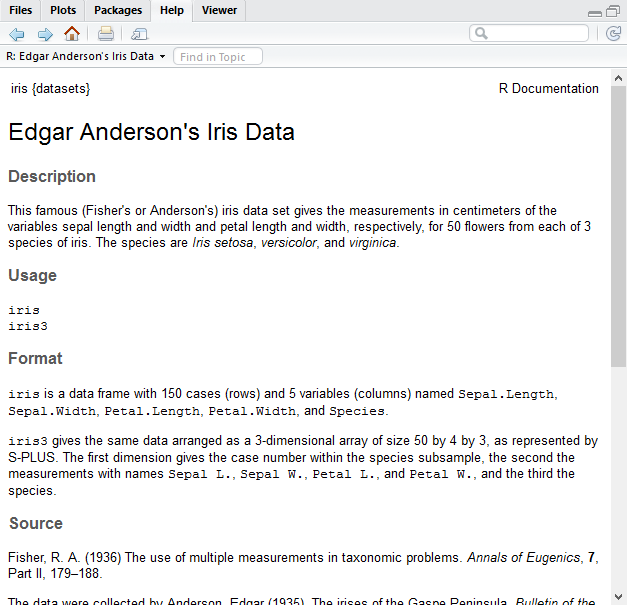

documentação de ajuda dao dataframe iris

Caso se rode apenas o nome do dataframe, o console fica poluído, pois será mostrado todo o dataframe no console, ou pelo menos as primeiras centenas de linhas:

```r
iris
```

| Sepal.Length | Sepal.Width | Petal.Length | Petal.Width | Species |
| --- | --- | --- | --- | --- |
| 5.1 | 3.5 | 1.4 | 0.2 | setosa |
| 4.9 | 3.0 | 1.4 | 0.2 | setosa |
| 4.7 | 3.2 | 1.3 | 0.2 | setosa |
| 4.6 | 3.1 | 1.5 | 0.2 | setosa |
| 5.0 | 3.6 | 1.4 | 0.2 | setosa |
| 5.4 | 3.9 | 1.7 | 0.4 | setosa |
| 4.6 | 3.4 | 1.4 | 0.3 | setosa |
| 5.0 | 3.4 | 1.5 | 0.2 | setosa |
| 4.4 | 2.9 | 1.4 | 0.2 | setosa |
| 4.9 | 3.1 | 1.5 | 0.1 | setosa |
| 5.4 | 3.7 | 1.5 | 0.2 | setosa |
| 4.8 | 3.4 | 1.6 | 0.2 | setosa |
| 4.8 | 3.0 | 1.4 | 0.1 | setosa |
| 4.3 | 3.0 | 1.1 | 0.1 | setosa |
| 5.8 | 4.0 | 1.2 | 0.2 | setosa |
| 5.7 | 4.4 | 1.5 | 0.4 | setosa |
| 5.4 | 3.9 | 1.3 | 0.4 | setosa |
| 5.1 | 3.5 | 1.4 | 0.3 | setosa |
| 5.7 | 3.8 | 1.7 | 0.3 | setosa |
| 5.1 | 3.8 | 1.5 | 0.3 | setosa |
| 5.4 | 3.4 | 1.7 | 0.2 | setosa |
| 5.1 | 3.7 | 1.5 | 0.4 | setosa |
| 4.6 | 3.6 | 1.0 | 0.2 | setosa |
| 5.1 | 3.3 | 1.7 | 0.5 | setosa |
| 4.8 | 3.4 | 1.9 | 0.2 | setosa |
| 5.0 | 3.0 | 1.6 | 0.2 | setosa |
| 5.0 | 3.4 | 1.6 | 0.4 | setosa |
| 5.2 | 3.5 | 1.5 | 0.2 | setosa |
| 5.2 | 3.4 | 1.4 | 0.2 | setosa |
| 4.7 | 3.2 | 1.6 | 0.2 | setosa |

[output cut: 120 more lines]

Uma melhor forma de se visualizar o dado e visualizar as primeiras e ultimas 6 linhas com head() e tail().

Primeiras 6 linhas:

```r
head(iris)
```

| Sepal.Length | Sepal.Width | Petal.Length | Petal.Width | Species |
| --- | --- | --- | --- | --- |
| 5.1 | 3.5 | 1.4 | 0.2 | setosa |
| 4.9 | 3.0 | 1.4 | 0.2 | setosa |
| 4.7 | 3.2 | 1.3 | 0.2 | setosa |
| 4.6 | 3.1 | 1.5 | 0.2 | setosa |
| 5.0 | 3.6 | 1.4 | 0.2 | setosa |
| 5.4 | 3.9 | 1.7 | 0.4 | setosa |

Ultimas 6 linhas:

```r
tail(iris)
```

|  | Sepal.Length | Sepal.Width | Petal.Length | Petal.Width | Species |
| --- | --- | --- | --- | --- | --- |
| 145 | 6.7 | 3.3 | 5.7 | 2.5 | virginica |
| 146 | 6.7 | 3.0 | 5.2 | 2.3 | virginica |
| 147 | 6.3 | 2.5 | 5.0 | 1.9 | virginica |
| 148 | 6.5 | 3.0 | 5.2 | 2.0 | virginica |
| 149 | 6.2 | 3.4 | 5.4 | 2.3 | virginica |
| 150 | 5.9 | 3.0 | 5.1 | 1.8 | virginica |

Iris da informações de largura e comprimento de sépalas e pétalas de flores por espécie. Pode-se verificar os nomes das variáveis de iris:

```r
names(iris)
```

```
## [1] "Sepal.Length" "Sepal.Width"  "Petal.Length" "Petal.Width"
## [5] "Species"
```

```r
iris$Species
```

```
##   [1] setosa     setosa     setosa     setosa     setosa     setosa
##   [7] setosa     setosa     setosa     setosa     setosa     setosa
##  [13] setosa     setosa     setosa     setosa     setosa     setosa
##  [19] setosa     setosa     setosa     setosa     setosa     setosa
##  [25] setosa     setosa     setosa     setosa     setosa     setosa
##  [31] setosa     setosa     setosa     setosa     setosa     setosa
##  [37] setosa     setosa     setosa     setosa     setosa     setosa
##  [43] setosa     setosa     setosa     setosa     setosa     setosa
##  [49] setosa     setosa     versicolor versicolor versicolor versicolor
##  [55] versicolor versicolor versicolor versicolor versicolor versicolor
##  [61] versicolor versicolor versicolor versicolor versicolor versicolor
##  [67] versicolor versicolor versicolor versicolor versicolor versicolor
##  [73] versicolor versicolor versicolor versicolor versicolor versicolor
##  [79] versicolor versicolor versicolor versicolor versicolor versicolor
##  [85] versicolor versicolor versicolor versicolor versicolor versicolor
##  [91] versicolor versicolor versicolor versicolor versicolor versicolor
##  [97] versicolor versicolor versicolor versicolor virginica  virginica
## [103] virginica  virginica  virginica  virginica  virginica  virginica
## [109] virginica  virginica  virginica  virginica  virginica  virginica
## [115] virginica  virginica  virginica  virginica  virginica  virginica
## [121] virginica  virginica  virginica  virginica  virginica  virginica
## [127] virginica  virginica  virginica  virginica  virginica  virginica
## [133] virginica  virginica  virginica  virginica  virginica  virginica
## [139] virginica  virginica  virginica  virginica  virginica  virginica
## [145] virginica  virginica  virginica  virginica  virginica  virginica
## Levels: setosa versicolor virginica
```

Observando a classe da variável Species, veremos que se trata de um fator:

```r
class(iris$Species)
```

```
## [1] "factor"
```

Um fator agrupa observações repetidas, e as separa em grupos; estes são chamados de levels, ou níveis.

Aqui obtem-se os nomes das 3 espécies neste dataframe:

```r
levels(iris$Species)
```

```
## [1] "setosa"     "versicolor" "virginica"
```

E se o objetivo fosse obter os dados de largura e comprimento apenas da espécie setosa?

Como a variável Species separa os dados nos níveis “setosa”, “versicolor”, “virginica”, basta filtrar iris com a variável Species, especificando que se deseja apenas os dados que estão dentro no nível “setosa”:

```r
iris[iris$Species=="setosa" , ]
```

| Sepal.Length | Sepal.Width | Petal.Length | Petal.Width | Species |
| --- | --- | --- | --- | --- |
| 5.1 | 3.5 | 1.4 | 0.2 | setosa |
| 4.9 | 3.0 | 1.4 | 0.2 | setosa |
| 4.7 | 3.2 | 1.3 | 0.2 | setosa |
| 4.6 | 3.1 | 1.5 | 0.2 | setosa |
| 5.0 | 3.6 | 1.4 | 0.2 | setosa |
| 5.4 | 3.9 | 1.7 | 0.4 | setosa |
| 4.6 | 3.4 | 1.4 | 0.3 | setosa |
| 5.0 | 3.4 | 1.5 | 0.2 | setosa |
| 4.4 | 2.9 | 1.4 | 0.2 | setosa |
| 4.9 | 3.1 | 1.5 | 0.1 | setosa |
| 5.4 | 3.7 | 1.5 | 0.2 | setosa |
| 4.8 | 3.4 | 1.6 | 0.2 | setosa |
| 4.8 | 3.0 | 1.4 | 0.1 | setosa |
| 4.3 | 3.0 | 1.1 | 0.1 | setosa |
| 5.8 | 4.0 | 1.2 | 0.2 | setosa |
| 5.7 | 4.4 | 1.5 | 0.4 | setosa |
| 5.4 | 3.9 | 1.3 | 0.4 | setosa |
| 5.1 | 3.5 | 1.4 | 0.3 | setosa |
| 5.7 | 3.8 | 1.7 | 0.3 | setosa |
| 5.1 | 3.8 | 1.5 | 0.3 | setosa |
| 5.4 | 3.4 | 1.7 | 0.2 | setosa |
| 5.1 | 3.7 | 1.5 | 0.4 | setosa |
| 4.6 | 3.6 | 1.0 | 0.2 | setosa |
| 5.1 | 3.3 | 1.7 | 0.5 | setosa |
| 4.8 | 3.4 | 1.9 | 0.2 | setosa |
| 5.0 | 3.0 | 1.6 | 0.2 | setosa |
| 5.0 | 3.4 | 1.6 | 0.4 | setosa |
| 5.2 | 3.5 | 1.5 | 0.2 | setosa |
| 5.2 | 3.4 | 1.4 | 0.2 | setosa |
| 4.7 | 3.2 | 1.6 | 0.2 | setosa |
| 4.8 | 3.1 | 1.6 | 0.2 | setosa |
| 5.4 | 3.4 | 1.5 | 0.4 | setosa |
| 5.2 | 4.1 | 1.5 | 0.1 | setosa |
| 5.5 | 4.2 | 1.4 | 0.2 | setosa |
| 4.9 | 3.1 | 1.5 | 0.2 | setosa |
| 5.0 | 3.2 | 1.2 | 0.2 | setosa |
| 5.5 | 3.5 | 1.3 | 0.2 | setosa |
| 4.9 | 3.6 | 1.4 | 0.1 | setosa |
| 4.4 | 3.0 | 1.3 | 0.2 | setosa |
| 5.1 | 3.4 | 1.5 | 0.2 | setosa |
| 5.0 | 3.5 | 1.3 | 0.3 | setosa |
| 4.5 | 2.3 | 1.3 | 0.3 | setosa |
| 4.4 | 3.2 | 1.3 | 0.2 | setosa |
| 5.0 | 3.5 | 1.6 | 0.6 | setosa |
| 5.1 | 3.8 | 1.9 | 0.4 | setosa |
| 4.8 | 3.0 | 1.4 | 0.3 | setosa |
| 5.1 | 3.8 | 1.6 | 0.2 | setosa |
| 4.6 | 3.2 | 1.4 | 0.2 | setosa |
| 5.3 | 3.7 | 1.5 | 0.2 | setosa |
| 5.0 | 3.3 | 1.4 | 0.2 | setosa |

Isto e chamado de subsetting; existe um tópico separado neste curso para estas operações.

# 5) Tipos de objetos (Modes)

No R, dados podem ser organizados em diferentes tipos, ou modos; as principais serão refenciadas neste tópico.

## 5.1) Vectors (vetores)

No R, um vetor é uma sequência de dados de mesma classe; vetores possuem apenas uma dimensão; um vetor pode ser criado com a função c(), que concatena valores:

```r
a <- c(1, 2, 5.3, 6, -2, 4)
a # vetor numérico
```

```
## [1]  1.0  2.0  5.3  6.0 -2.0  4.0
```

```r
b <- c("um", "dois", "tres")
b # vetor character
```

```
## [1] "um"   "dois" "tres"
```

```r
c <- c(TRUE,TRUE,TRUE,FALSE,TRUE,FALSE)
c # vetor logical
```

```
## [1]  TRUE  TRUE  TRUE FALSE  TRUE FALSE
```

Ao se tentar unir strings e números, ou seja, objetos de classes diferentes em um único vetor, os números serão “coagidos” (coerced) para caracteres, pois um vetor so pode ter uma classe:

```r
# atenção aos números entre aspas, indicando que eles na verdade são caracteres:
c(a, b)
```

```
## [1] "1"    "2"    "5.3"  "6"    "-2"   "4"    "um"   "dois" "tres"
```

## 5.2) Matrices (Matrizes)

No R, uma matriz é um conjunto de elementos organizados de forma retangular bidimensional; Todas as colunas de uma matriz devem ter o mesmo número de elementos e a mesma classe(numeric,character, etc).

Pode-se criar uma matriz com a função matrix():

```r
d <- matrix(
  c(2, 4, 3, 1), # dados a serem inseridos
  nrow=2,              # número de linhas
  ncol=2,              # número de colunas
  byrow = TRUE)        # organizar a matriz por linha
```

matriz que vai de 1 a 4, com duas linhas, organizada por coluna:

```r
e <- matrix(1:4, nrow = 2,byrow = FALSE)
```

matriz d no console:

```r
d
```

```
##      [,1] [,2]
## [1,]    2    4
## [2,]    3    1
```

Pode-se fazer operações matemáticas com matrizes: Multiplicação:

```r
d * 4
```

```
##      [,1] [,2]
## [1,]    8   16
## [2,]   12    4
```

Multiplicação de matrizes:

```r
d %*% e
```

```
##      [,1] [,2]
## [1,]   10   22
## [2,]    5   13
```

Matriz transposta:

```r
t(d)
```

```
##      [,1] [,2]
## [1,]    2    3
## [2,]    4    1
```

Matriz Inversa:

```r
solve(d)
```

```
##      [,1] [,2]
## [1,] -0.1  0.4
## [2,]  0.3 -0.2
```

elementos de uma matriz podem ser referenciados utilizando [], utilizando df[linha, coluna], por exemplo: Primeira linha, segunda coluna:

```r
d[1,2]
```

```
## [1] 4
```

Todos os objetos da segunda linha:

```r
d[2, ]
```

```
## [1] 3 1
```

mais detalhes sobre manipulação de matrizes serão abordados em tópicos futuros.

## 5.3) Data Frames

Dataframes (df) são a forma padrão de se inserir dados no R. Um data frame é mais geral do que uma matriz, de forma que diferentes colunas podem ter diferentes classes.

Colunas são chamadas de variáveis (variables) e linhas de observações (observations);

Pode-se utilizar vetores para criar um data frame:

```r
a <- c(1, 2, 3, 4)
b <- c("vermelho", "azul", "vermelho", "rosa")
c <- c(TRUE,TRUE,TRUE,FALSE)

meusdados <- data.frame(a,b,c)
meusdados
```

| a | b | c |
| --- | --- | --- |
| 1 | vermelho | TRUE |
| 2 | azul | TRUE |
| 3 | vermelho | TRUE |
| 4 | rosa | FALSE |

Observa-se que agora na aba “environment, abaixo de Data, existe o df”meusdados“, com 4 observações e 3 variáveis, ou seja, 4 linhas e 3 colunas.

Outra forma de verificar isto e com a função dim():

```r
dim(meusdados)
```

```
## [1] 4 3
```

Os nomes das variáveis de um df podem ser alterados:

```r
names(meusdados) <- c("Idade", "ID", "Teste")
meusdados
```

| Idade | ID | Teste |
| --- | --- | --- |
| 1 | vermelho | TRUE |
| 2 | azul | TRUE |
| 3 | vermelho | TRUE |
| 4 | rosa | FALSE |

Pode-se visualizá-lo como uma tabela, clicando nele na aba environment, ou utilizando View:

```r
# View(meusdados)
```

o R possui dataframes built-in, ou seja, que já vem instalados com o a instalação básica:

```r
head(mtcars)
```

|  | mpg | cyl | disp | hp | drat | wt | qsec | vs | am | gear | carb |
| --- | --- | --- | --- | --- | --- | --- | --- | --- | --- | --- | --- |
| Mazda RX4 | 21.0 | 6 | 160 | 110 | 3.90 | 2.620 | 16.46 | 0 | 1 | 4 | 4 |
| Mazda RX4 Wag | 21.0 | 6 | 160 | 110 | 3.90 | 2.875 | 17.02 | 0 | 1 | 4 | 4 |
| Datsun 710 | 22.8 | 4 | 108 | 93 | 3.85 | 2.320 | 18.61 | 1 | 1 | 4 | 1 |
| Hornet 4 Drive | 21.4 | 6 | 258 | 110 | 3.08 | 3.215 | 19.44 | 1 | 0 | 3 | 1 |
| Hornet Sportabout | 18.7 | 8 | 360 | 175 | 3.15 | 3.440 | 17.02 | 0 | 0 | 3 | 2 |
| Valiant | 18.1 | 6 | 225 | 105 | 2.76 | 3.460 | 20.22 | 1 | 0 | 3 | 1 |

```r
head(iris)
```

| Sepal.Length | Sepal.Width | Petal.Length | Petal.Width | Species |
| --- | --- | --- | --- | --- |
| 5.1 | 3.5 | 1.4 | 0.2 | setosa |
| 4.9 | 3.0 | 1.4 | 0.2 | setosa |
| 4.7 | 3.2 | 1.3 | 0.2 | setosa |
| 4.6 | 3.1 | 1.5 | 0.2 | setosa |
| 5.0 | 3.6 | 1.4 | 0.2 | setosa |
| 5.4 | 3.9 | 1.7 | 0.4 | setosa |

mais detalhes sobre a manipulação de data frames serão abordados em tópicos futuros.

## 5.4) Lists (Listas)

Listas são coleções ordenadas de objetos; Podem unir objetos de diferentes tipos, classes e domensões em um único objeto. São uteis quando se quer unir informações de objetos de domensões diferentes, e na otimização de loops.

Por exemplo: Um dataframe e um vetor podem ser unidos por uma lista:

```r
meusdados <- data.frame(a = c(1, 2, 3, 4),
                        b = c("vermelho", "azul", "vermelho", "rosa"),
                        c = c(TRUE, TRUE, TRUE, FALSE))

d <- matrix( c(2, 4, 3, 1),   nrow=2, byrow = TRUE)

minhalista <- list(d, meusdados)

minhalista
```

```
## [[1]]
##      [,1] [,2]
## [1,]    2    4
## [2,]    3    1
##
## [[2]]
##   a        b     c
## 1 1 vermelho  TRUE
## 2 2     azul  TRUE
## 3 3 vermelho  TRUE
## 4 4     rosa FALSE
```

```r
class(minhalista)
```

```
## [1] "list"
```

Elementos de uma lista são identificados utilizando [[]] primeiro elemento de uma lista:

```r
minhalista[[1]]
```

```
##      [,1] [,2]
## [1,]    2    4
## [2,]    3    1
```

segundo elemento de uma lista:

```r
minhalista[[2]]
```

| a | b | c |
| --- | --- | --- |
| 1 | vermelho | TRUE |
| 2 | azul | TRUE |
| 3 | vermelho | TRUE |
| 4 | rosa | FALSE |

observa-se que a classe do objeto não se altera dentro da lista:

```r
class(minhalista[[1]])
```

```
## [1] "matrix"
```

Caso seja utilizado apenas um colchete, a classe do objeto será de uma lista:

```r
class(minhalista[1])
```

```
## [1] "list"
```

## 5.5) Functions (funções)

funções são formas de se compactar rotinas ou operações complexas, que se deseja fazer repetidas vezes, em apenas um comando, facilitando a digitação, diminuindo o tamanho de scripts, etc.

O R possui funções que são nativas dele, que podem ser acessadas assim que se abre o programa. Estas são as funções conhecidas como base. Novas funções podem ser adquiridas por meio de pacotes, ou podem ser criadas pelo próprio usuário.

Para acessar uma função do R base, basta digitar o nome dela, seguido de um parênteses. Por exemplo:

```r
sum(4,5)
```

```
## [1] 9
```

Todas as funções no R possuem argumentos. Argumentos são as entradas da função, que são separados por “,” . Por exemplo, para se descobrir os argumentos função matrix, usa-se o comando:

```r
args(matrix)
```

```
## function (data = NA, nrow = 1, ncol = 1, byrow = FALSE, dimnames = NULL)
## NULL
```

Para se saber mais sobre uma função, basta utilizar ? seguido do nome da função:

```r
?matrix
```

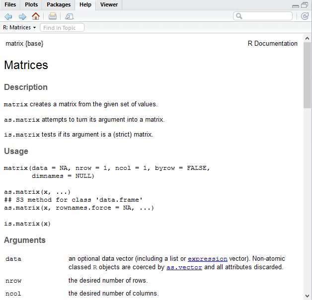

documentação de ajuda da função matrix

Agora se tem uma descrição detalhada da função. Com isso, conclui-se que:

```r
matrix()
```

```
##      [,1]
## [1,]   NA
```

Caso se altere estes argumentos, altera-se a saída:

```r
matrix(1)
```

```
##      [,1]
## [1,]    1
```

```r
matrix(1, nrow = 2 )
```

```
##      [,1]
## [1,]    1
## [2,]    1
```

```r
matrix(1, nrow = 2, ncol = 2 )
```

```
##      [,1] [,2]
## [1,]    1    1
## [2,]    1    1
```

Algumas funções não funcionam sem uma entrada, como por exemplo, summary. Summary nos da um resumo de um determinado objeto.

```r
args(summary)
```

```
## function (object, ...)
## NULL
```

não existe default para o argumento object, indicando que ele e um argumento obrigatório. Se a função for rodada sem uma entrada, ela irá gerar um erro:

```r
#summary()
```

Agora caso inserido um dataframe como entrada, a função retorna média, quartis, mediana, mínimo e máximo de cada variável:

```r
summary(mtcars)
```

```
##       mpg             cyl             disp             hp
##  Min.   :10.40   Min.   :4.000   Min.   : 71.1   Min.   : 52.0
##  1st Qu.:15.43   1st Qu.:4.000   1st Qu.:120.8   1st Qu.: 96.5
##  Median :19.20   Median :6.000   Median :196.3   Median :123.0
##  Mean   :20.09   Mean   :6.188   Mean   :230.7   Mean   :146.7
##  3rd Qu.:22.80   3rd Qu.:8.000   3rd Qu.:326.0   3rd Qu.:180.0
##  Max.   :33.90   Max.   :8.000   Max.   :472.0   Max.   :335.0
##       drat             wt             qsec             vs
##  Min.   :2.760   Min.   :1.513   Min.   :14.50   Min.   :0.0000
##  1st Qu.:3.080   1st Qu.:2.581   1st Qu.:16.89   1st Qu.:0.0000
##  Median :3.695   Median :3.325   Median :17.71   Median :0.0000
##  Mean   :3.597   Mean   :3.217   Mean   :17.85   Mean   :0.4375
##  3rd Qu.:3.920   3rd Qu.:3.610   3rd Qu.:18.90   3rd Qu.:1.0000
##  Max.   :4.930   Max.   :5.424   Max.   :22.90   Max.   :1.0000
##        am              gear            carb
##  Min.   :0.0000   Min.   :3.000   Min.   :1.000
##  1st Qu.:0.0000   1st Qu.:3.000   1st Qu.:2.000
##  Median :0.0000   Median :4.000   Median :2.000
##  Mean   :0.4062   Mean   :3.688   Mean   :2.812
##  3rd Qu.:1.0000   3rd Qu.:4.000   3rd Qu.:4.000
##  Max.   :1.0000   Max.   :5.000   Max.   :8.000
```

# 6) Pacotes

Pacotes são a unidade fundamental de código reproduzível no R. Eles incluem funções do R reutilizáveis, a documentação que explica como utilizá-la, e dados de exemplo. Geralmente pacotes são feitos com um propósito específico, que facilita alguma operação que se deseja fazer no R, como por exemplo facilitar a manipulação de dados, gráficos mais complexos e bonitos, importação de arquivos que por padrão não são aceitos no R, entre outros.

Qualquer pessoa pode criar um pacote e compartilhá-lo. Mas, para que ele se torne um pacote “oficial” do R, deve ser enviado para o CRAN, onde passa por uma rigorosa analise, ate que seja aceito e disponível para download pelo mesmo.

Para se instalar pacotes utiliza-se a função install.packages.

Para instalar um pacote basta rodar a função inserindo o nome do pacote entre aspas.

É interessante sempre utilizar o argumento dependencies com valor TRUE, para que seja instalado junto com o pacote, todos os pacotes que este precisa para funcionar corretamente. A seguir exemplifica-se a instalação do pacote dplyr:

```r
#install.packages("dplyr", dependencies = TRUE)
```

Esta operação e feita uma unica vez, e precisa ser refeita apenas quando se deseja atualizar o pacote.

Para se carregar um pacote, basta utilizar a função library ou require:

```r
library(dplyr)
```

ou:

```r
require(dplyr)
```

É necessário carregar um pacote que se deseja utilizar sempre que se iniciar uma nova seção, ou seja, sempre que se abrir o programa.

A seguir, uma lista dos pacotes mais utilizados e recomendados:

1. tidyverse - É um conjunto de pacotes para ciência de dados. inclui alguns dos pacotes mais utilizados no mundo, como dplyr, ggplot2, entre outros. Alguns destes serão detalhados abaixo. É muito recomendado explorar todos os pacotes inclusos no tidyverse.
2. dplyr - para manipulação de dados. Composto por funções simples e fáceis de usar que resolvem a maioria dos problemas envolvendo manipulação de dados;
3. tidyr - Organização dos dados. Transformar tabelas longas, unir variáveis, lidar com NA, etc;
4. readxl - para carregar arquivos direto do excel em formato .xlsx;
5. ggplot2 - para criação de gráficos bonitos e customizáveis;
6. raster - para manipulação de imagens e shape files no R;
7. ExpDes.pt - Pacote destinado a analise de delineamentos experimentais (todo em portugues);
8. agricolae - Pacote destinado a analise de delineamentos experimentais;
9. vegan - Pacote utilizado para análises descritivas de ecologia;

A única desvantagem em se utilizar pacotes, é que pode acontecer do pacote ser atualizado e uma função mudar de nome, ou deixar de existir, deixando códigos antigos inutilizados. [Códigos escritos utilizando as funções padrões do R, também conhecidas como r base são mais recomendados.

# 7) Importar dados no R

Pode-se importar e exportar dados no R base (sem a utilização de pacotes) pelos formatos .csv e .txt; os dois formatos são semelhantes em questão de tamanho e velocidade, fica a critério do usuário qual tipo de arquivo utilizar.

utiliza-se read.csv2 para arquivos com separador “;” e dec “,” (padrão nacional/europeu); e read.csv para arquivos com separador “,” e dec “.” (padrão americano).

As funções de importação de dados tem como primeiro argumento o caminho em que o arquivo que se deseja importar se encontra. Por exemplo, se o arquivo estivesse na pasta R, de meus documentos, e o nome do arquivo fosse dados, e seu formato csv, o seu caminho seria:

D:/Meus Documentos/R/dados.csv

Digita-se o caminho, seguido do nome do objeto e a sua extensão. Caso o objeto esteja dentro da pasta da área de trabalho, basta digitar o nome do arquivo e sua extensão, que ele será importado. Por exemplo: Importa-se dados inserindo o caminho completo:

```r
dados <- read.csv2(file = "C:/Users/solla/Documents/R/aulas_cursos/nocoes_R/dados.csv" )
```

Digitando-se apenas o nome do arquivo, localizado no diretório de trabalho:

```r
dados <- read.csv2("dados.csv")
```

O dado anterior foi salvo utilizando o padrão brasileiro de separador e decimal. Caso o arquivo possua o padrão americano, deve-se usar a função read.csv, ou altera-se os argumentos de dec e sep.

Para se importar dados em .txt, utiliza-se read.table. Deve-se alterar o argumento header para TRUE, pois o padrão e FALSE, e especificar o separador, dependendo do padrão utilizado:

```r
dados <- read.table("C:/Users/solla/Documents/R/aulas_cursos/nocoes_R/dados.txt",
                    header = T, dec = ",", sep = "\t")

dados <- read.table("dados.txt", header = T, dec = ",", sep = "\t")
```

Caso seja utilizada a IDE RStudio, também e possível importar dados pelo menu “import dataset”, na aba environment.

porém e recomendado utilizar-se das linhas de comando, para que se ganhe familiaridade com o programa, e para que os scripts criados futuramente tenham a importação dos dados nele, tornando-os mais práticos.

Importar dados direto em formato excel

Isto pode ser feito utilizando o pacote readxl:

```r
library(readxl)
teste <- read_xlsx("dados.xlsx")
teste
```

| CODTALHAO | CODPARCELA | CODARVORE | CAP | ALT1 | DESCCATEGORIA |
| --- | --- | --- | --- | --- | --- |
| 3656 | 101 | 101 | 51.2 | 21.5 | Normal |
| 3656 | 101 | 103 | 52.2 | 20.9 | Normal |
| 3656 | 101 | 201 | 22.6 | NA | Outros Fustes |
| 3656 | 101 | 203 | 56.0 | 21.7 | Normal |
| 3656 | 101 | 205 | 45.2 | 20.5 | Normal |
| 3656 | 101 | 302 | 58.4 | 21.6 | Dominante |
| 3656 | 101 | 304 | 62.9 | NA | Bifurcadaacima1.30 |
| 3656 | 101 | 306 | 53.8 | NA | Inclinada |
| 3656 | 101 | 402 | 43.7 | NA | Inclinada |
| 3656 | 101 | 404 | 46.5 | NA | Normal |
| 3656 | 101 | 502 | 41.0 | NA | Normal |
| 3656 | 102 | 101 | 47.7 | 20.1 | Normal |
| 3656 | 102 | 103 | 43.7 | NA | Bifurcadaacima1.30 |
| 3656 | 102 | 202 | 47.3 | 20.4 | Normal |
| 3656 | 102 | 204 | 52.3 | 21.1 | Normal |
| 3656 | 102 | 301 | 49.8 | 20.6 | Normal |
| 3656 | 102 | 303 | 46.0 | NA | Normal |
| 3656 | 102 | 305 | 56.1 | 21.5 | Dominante |
| 3656 | 102 | 401 | 38.4 | NA | Normal |
| 3656 | 102 | 403 | 51.7 | NA | Normal |
| 3656 | 102 | 405 | 47.0 | NA | Normal |
| 3656 | 102 | 501 | 55.3 | NA | Normal |
| 3656 | 102 | 503 | 54.2 | NA | Normal |
| 3656 | 103 | 101 | 58.2 | NA | Bifurcadaacima1.30 |
| 3656 | 103 | 201 | 50.1 | NA | Bifurcadaabaixo1.30 |
| 3656 | 103 | 202 | 52.6 | 21.4 | Normal |
| 3656 | 103 | 204 | 42.4 | 19.7 | Normal |
| 3656 | 103 | 302 | 50.9 | 20.9 | Normal |
| 3656 | 103 | 304 | 55.1 | 21.4 | Dominante |
| 3656 | 103 | 305 | 37.4 | NA | Outros Fustes |

[output cut: 52 more lines]

# 8) Indexar ou extrair partes de um objeto (subsetting) e lógica

## 8.1) Subsetting

Quando se trata de dataframes, pode-se utilizar $ para selecionar uma coluna especifica por nome, ou [] para especificar uma linha e/ou coluna especifica por posição.

Utilizando [], primeiro especifica-se a linha, e depois a coluna, separados por “,”; caso um destes espaços fiquem vazios, toda a seção e selecionada.

Primeiramente importa-se o dado que será utilizado neste capitulo:

```r
dados <- read.csv2("dados.csv")
head(dados)
```

| CODTALHAO | CODPARCELA | CODARVORE | CAP | ALT1 | DESCCATEGORIA |
| --- | --- | --- | --- | --- | --- |
| 3656 | 101 | 101 | 51.2 | 21.5 | Normal |
| 3656 | 101 | 103 | 52.2 | 20.9 | Normal |
| 3656 | 101 | 201 | 22.6 | NA | Outros Fustes |
| 3656 | 101 | 203 | 56.0 | 21.7 | Normal |
| 3656 | 101 | 205 | 45.2 | 20.5 | Normal |
| 3656 | 101 | 302 | 58.4 | 21.6 | Dominante |

Utilizando o dataframe dados, pode-se selecionar apenas a variável CAP, utilizando $:

```r
dados$CAP
```

```
##  [1] 51.2 52.2 22.6 56.0 45.2 58.4 62.9 53.8 43.7 46.5 41.0 47.7 43.7 47.3
## [15] 52.3 49.8 46.0 56.1 38.4 51.7 47.0 55.3 54.2 58.2 50.1 52.6 42.4 50.9
## [29] 55.1 37.4 48.8 50.7 52.3 47.0 57.5 54.7 50.6   NA 57.0 51.7 46.7 57.8
## [43] 50.8 51.0 56.6 53.2 51.3 53.2 54.0 55.8 59.0 40.5 58.9   NA 53.6 57.7
## [57] 55.5   NA 24.2 29.7 50.9 53.6 50.5   NA 52.4   NA   NA 65.5 52.8 24.5
## [71] 56.1 53.5 55.4 53.1 49.3 52.1 49.3 49.8 57.4 58.1 54.0 50.2
```

Com isso pode-se pedir a média do CAP; É importante utilizar o argumento na.rm, que remove qualquer na contido no dado:

```r
mean(dados$CAP, na.rm = T)
```

```
## [1] 50.5
```

Caso tente-se rodar apenas o nome da variável gera-se um erro:

```r
# CAP
```

Isso ocorre porque quando se roda o nome, o R procura um objeto com este nome no ambiente, e não encontra, gerando o erro. Para que se possa chamar variáveis por nome sem $, precisa-se utilizar a função attach, que fixa o dado no ambiente:

```r
attach(dados)
```

Agora, chamar o nome da variável não gera erro:

```r
CAP
```

```
##  [1] 51.2 52.2 22.6 56.0 45.2 58.4 62.9 53.8 43.7 46.5 41.0 47.7 43.7 47.3
## [15] 52.3 49.8 46.0 56.1 38.4 51.7 47.0 55.3 54.2 58.2 50.1 52.6 42.4 50.9
## [29] 55.1 37.4 48.8 50.7 52.3 47.0 57.5 54.7 50.6   NA 57.0 51.7 46.7 57.8
## [43] 50.8 51.0 56.6 53.2 51.3 53.2 54.0 55.8 59.0 40.5 58.9   NA 53.6 57.7
## [57] 55.5   NA 24.2 29.7 50.9 53.6 50.5   NA 52.4   NA   NA 65.5 52.8 24.5
## [71] 56.1 53.5 55.4 53.1 49.3 52.1 49.3 49.8 57.4 58.1 54.0 50.2
```

porém, quando se trabalha com mais de um dataframe, ou com scripts longos, fixar dados pode gerar erros e atrapalhar o fluxo do script. Por isso a maioria dos usuários não recomenda o uso do attach.

Para desafixar dados, basta utilizar detach:

```r
detach(dados)
```

Uma outra forma de selecionar a coluna CAP e utilizando []; utilizando head(), percebe-se que a coluna CAP está na posição 4:

```r
head(dados)
```

| CODTALHAO | CODPARCELA | CODARVORE | CAP | ALT1 | DESCCATEGORIA |
| --- | --- | --- | --- | --- | --- |
| 3656 | 101 | 101 | 51.2 | 21.5 | Normal |
| 3656 | 101 | 103 | 52.2 | 20.9 | Normal |
| 3656 | 101 | 201 | 22.6 | NA | Outros Fustes |
| 3656 | 101 | 203 | 56.0 | 21.7 | Normal |
| 3656 | 101 | 205 | 45.2 | 20.5 | Normal |
| 3656 | 101 | 302 | 58.4 | 21.6 | Dominante |

Portando, pode-se utilizar [] para selecionar a coluna CAP, posicionando o número 4 do lado direito da virgula, indicando posição de coluna:

```r
dados[ , 4]
```

```
##  [1] 51.2 52.2 22.6 56.0 45.2 58.4 62.9 53.8 43.7 46.5 41.0 47.7 43.7 47.3
## [15] 52.3 49.8 46.0 56.1 38.4 51.7 47.0 55.3 54.2 58.2 50.1 52.6 42.4 50.9
## [29] 55.1 37.4 48.8 50.7 52.3 47.0 57.5 54.7 50.6   NA 57.0 51.7 46.7 57.8
## [43] 50.8 51.0 56.6 53.2 51.3 53.2 54.0 55.8 59.0 40.5 58.9   NA 53.6 57.7
## [57] 55.5   NA 24.2 29.7 50.9 53.6 50.5   NA 52.4   NA   NA 65.5 52.8 24.5
## [71] 56.1 53.5 55.4 53.1 49.3 52.1 49.3 49.8 57.4 58.1 54.0 50.2
```

Como o lado esquerdo está vazio, todas as linhas são mostradas.

Pode-se utilizar o argumento drop=F, para se manter a classe de dataframe, ao invés de converte-la em vetor:

```r
dados[ , 4, drop = F]
```

| CAP |
| --- |
| 51.2 |
| 52.2 |
| 22.6 |
| 56.0 |
| 45.2 |
| 58.4 |
| 62.9 |
| 53.8 |
| 43.7 |
| 46.5 |
| 41.0 |
| 47.7 |
| 43.7 |
| 47.3 |
| 52.3 |
| 49.8 |
| 46.0 |
| 56.1 |
| 38.4 |
| 51.7 |
| 47.0 |
| 55.3 |
| 54.2 |
| 58.2 |
| 50.1 |
| 52.6 |
| 42.4 |
| 50.9 |
| 55.1 |
| 37.4 |

[output cut: 52 more lines]

Para mostrar apenas as 10 primeiras linhas, e a coluna 4, utiliza-se o seguinte comando:

```r
dados[1:10 , 4]
```

```
##  [1] 51.2 52.2 22.6 56.0 45.2 58.4 62.9 53.8 43.7 46.5
```

Utilizando [] também é possível especificar uma ou mais colunas por nome, porém este deve estar entre aspas:

```r
dados["CAP"]
```

| CAP |
| --- |
| 51.2 |
| 52.2 |
| 22.6 |
| 56.0 |
| 45.2 |
| 58.4 |
| 62.9 |
| 53.8 |
| 43.7 |
| 46.5 |
| 41.0 |
| 47.7 |
| 43.7 |
| 47.3 |
| 52.3 |
| 49.8 |
| 46.0 |
| 56.1 |
| 38.4 |
| 51.7 |
| 47.0 |
| 55.3 |
| 54.2 |
| 58.2 |
| 50.1 |
| 52.6 |
| 42.4 |
| 50.9 |
| 55.1 |
| 37.4 |

[output cut: 52 more lines]

Para selecionar mais de uma coluna, os nomes devem estar concatenados com a função c():

```r
dados[c("CAP" , "ALT1")]
```

| CAP | ALT1 |
| --- | --- |
| 51.2 | 21.5 |
| 52.2 | 20.9 |
| 22.6 | NA |
| 56.0 | 21.7 |
| 45.2 | 20.5 |
| 58.4 | 21.6 |
| 62.9 | NA |
| 53.8 | NA |
| 43.7 | NA |
| 46.5 | NA |
| 41.0 | NA |
| 47.7 | 20.1 |
| 43.7 | NA |
| 47.3 | 20.4 |
| 52.3 | 21.1 |
| 49.8 | 20.6 |
| 46.0 | NA |
| 56.1 | 21.5 |
| 38.4 | NA |
| 51.7 | NA |
| 47.0 | NA |
| 55.3 | NA |
| 54.2 | NA |
| 58.2 | NA |
| 50.1 | NA |
| 52.6 | 21.4 |
| 42.4 | 19.7 |
| 50.9 | 20.9 |
| 55.1 | 21.4 |
| 37.4 | NA |

[output cut: 52 more lines]

## 8.2) Logica e subsetting (Filtrar)

quando se faz testes lógicos entre dataframes, utilizando operadores lógicos, como >, < ==, gera-se um vetor lógico (ou booleano). Por exemplo, se pergunta-se quais dados de CAP são maiores que 50, gera-se o seguinte vetor:

```r
dados$CAP > 50
```

```
##  [1]  TRUE  TRUE FALSE  TRUE FALSE  TRUE  TRUE  TRUE FALSE FALSE FALSE
## [12] FALSE FALSE FALSE  TRUE FALSE FALSE  TRUE FALSE  TRUE FALSE  TRUE
## [23]  TRUE  TRUE  TRUE  TRUE FALSE  TRUE  TRUE FALSE FALSE  TRUE  TRUE
## [34] FALSE  TRUE  TRUE  TRUE    NA  TRUE  TRUE FALSE  TRUE  TRUE  TRUE
## [45]  TRUE  TRUE  TRUE  TRUE  TRUE  TRUE  TRUE FALSE  TRUE    NA  TRUE
## [56]  TRUE  TRUE    NA FALSE FALSE  TRUE  TRUE  TRUE    NA  TRUE    NA
## [67]    NA  TRUE  TRUE FALSE  TRUE  TRUE  TRUE  TRUE FALSE  TRUE FALSE
## [78] FALSE  TRUE  TRUE  TRUE  TRUE
```

Caso um vetor lógico seja inserido dentro de [], apenas as linhas em que se tem o valor TRUE são mantidas.

Com este raciocínio pode-se filtrar o dado. por exemplo:

```r
dados[dados$CAP > 50 , ]
```

|  | CODTALHAO | CODPARCELA | CODARVORE | CAP | ALT1 | DESCCATEGORIA |
| --- | --- | --- | --- | --- | --- | --- |
| 1 | 3656 | 101 | 101 | 51.2 | 21.5 | Normal |
| 2 | 3656 | 101 | 103 | 52.2 | 20.9 | Normal |
| 4 | 3656 | 101 | 203 | 56.0 | 21.7 | Normal |
| 6 | 3656 | 101 | 302 | 58.4 | 21.6 | Dominante |
| 7 | 3656 | 101 | 304 | 62.9 | NA | Bifurcadaacima1.30 |
| 8 | 3656 | 101 | 306 | 53.8 | NA | Inclinada |
| 15 | 3656 | 102 | 204 | 52.3 | 21.1 | Normal |
| 18 | 3656 | 102 | 305 | 56.1 | 21.5 | Dominante |
| 20 | 3656 | 102 | 403 | 51.7 | NA | Normal |
| 22 | 3656 | 102 | 501 | 55.3 | NA | Normal |
| 23 | 3656 | 102 | 503 | 54.2 | NA | Normal |
| 24 | 3656 | 103 | 101 | 58.2 | NA | Bifurcadaacima1.30 |
| 25 | 3656 | 103 | 201 | 50.1 | NA | Bifurcadaabaixo1.30 |
| 26 | 3656 | 103 | 202 | 52.6 | 21.4 | Normal |
| 28 | 3656 | 103 | 302 | 50.9 | 20.9 | Normal |
| 29 | 3656 | 103 | 304 | 55.1 | 21.4 | Dominante |
| 32 | 3656 | 103 | 402 | 50.7 | NA | Normal |
| 33 | 3656 | 103 | 404 | 52.3 | NA | Normal |
| 35 | 3656 | 104 | 101 | 57.5 | 20.5 | Normal |
| 36 | 3656 | 104 | 201 | 54.7 | 21.1 | Normal |
| 37 | 3656 | 104 | 203 | 50.6 | NA | Bifurcadaacima1.30 |
| NA | NA | NA | NA | NA | NA | NA |
| 39 | 3656 | 104 | 302 | 57.0 | 22.2 | Normal |
| 40 | 3656 | 104 | 304 | 51.7 | NA | Normal |
| 42 | 3656 | 104 | 404 | 57.8 | 21.6 | Dominante |
| 43 | 3656 | 104 | 502 | 50.8 | NA | Normal |
| 44 | 3654 | 101 | 101 | 51.0 | 29.2 | Normal |
| 45 | 3654 | 101 | 202 | 56.6 | 30.6 | Normal |
| 46 | 3654 | 101 | 204 | 53.2 | 28.8 | Normal |
| 47 | 3654 | 101 | 302 | 51.3 | 29.0 | Normal |
| 48 | 3654 | 101 | 304 | 53.2 | NA | Normal |
| 49 | 3654 | 101 | 401 | 54.0 | NA | Normal |
| 50 | 3654 | 101 | 403 | 55.8 | NA | Normal |
| 51 | 3654 | 101 | 405 | 59.0 | 30.2 | Dominante |
| 53 | 3654 | 102 | 101 | 58.9 | 32.5 | Normal |
| NA.1 | NA | NA | NA | NA | NA | NA |
| 55 | 3654 | 102 | 202 | 53.6 | 28.9 | Normal |
| 56 | 3654 | 102 | 204 | 57.7 | 29.8 | Normal |
| 57 | 3654 | 102 | 302 | 55.5 | 29.7 | Normal |
| NA.2 | NA | NA | NA | NA | NA | NA |
| 61 | 3654 | 102 | 403 | 50.9 | NA | Normal |
| 62 | 3654 | 102 | 405 | 53.6 | NA | Normal |
| 63 | 3654 | 102 | 502 | 50.5 | NA | Normal |
| NA.3 | NA | NA | NA | NA | NA | NA |
| 65 | 3654 | 103 | 201 | 52.4 | 29.5 | Normal |
| NA.4 | NA | NA | NA | NA | NA | NA |
| NA.5 | NA | NA | NA | NA | NA | NA |
| 68 | 3654 | 103 | 303 | 65.5 | 30.8 | Dominante |
| 69 | 3654 | 103 | 305 | 52.8 | 28.6 | Normal |
| 71 | 3654 | 103 | 403 | 56.1 | 27.8 | Normal |
| 72 | 3654 | 103 | 405 | 53.5 | NA | Normal |
| 73 | 3654 | 103 | 502 | 55.4 | NA | Normal |
| 74 | 3654 | 104 | 101 | 53.1 | 27.7 | Normal |
| 76 | 3654 | 104 | 202 | 52.1 | 30.2 | Normal |
| 79 | 3654 | 104 | 304 | 57.4 | 29.1 | Dominante |
| 80 | 3654 | 104 | 402 | 58.1 | 29.3 | Dominante |
| 81 | 3654 | 104 | 404 | 54.0 | NA | Normal |
| 82 | 3654 | 104 | 501 | 50.2 | NA | Normal |

Com isso, fatores são muito uteis quando se deseja filtrar os dados. Por exemplo, a variável DESCCATEGORIA indica a qualidade da arvore, como dominante, normal, falha, etc. Pode-se verificar isso com a função levels:

```r
levels(dados$DESCCATEGORIA)
```

```
## [1] "Bifurcadaabaixo1.30" "Bifurcadaacima1.30"  "Dominada"
## [4] "Dominante"           "Falha"               "Inclinada"
## [7] "Normal"              "Outros Fustes"
```

Seguindo o raciocínio, pode-se selecionar apenas as arvores dominantes:

```r
dados[dados$DESCCATEGORIA == "Dominante", ]
```

|  | CODTALHAO | CODPARCELA | CODARVORE | CAP | ALT1 | DESCCATEGORIA |
| --- | --- | --- | --- | --- | --- | --- |
| 6 | 3656 | 101 | 302 | 58.4 | 21.6 | Dominante |
| 18 | 3656 | 102 | 305 | 56.1 | 21.5 | Dominante |
| 29 | 3656 | 103 | 304 | 55.1 | 21.4 | Dominante |
| 42 | 3656 | 104 | 404 | 57.8 | 21.6 | Dominante |
| 51 | 3654 | 101 | 405 | 59.0 | 30.2 | Dominante |
| 68 | 3654 | 103 | 303 | 65.5 | 30.8 | Dominante |
| 79 | 3654 | 104 | 304 | 57.4 | 29.1 | Dominante |
| 80 | 3654 | 104 | 402 | 58.1 | 29.3 | Dominante |

Aqui seleciona-se apenas as linhas em que DESCCATEGORIA é igual a dominante, e todas as colunas.

Quando se realiza subsetting, é possível utilizar varias condições, deixando o filtro mais específico. O uso dos operadores & (E) e | (ou) são muito utilizados, pois especificam mutualidade exclusiva:

No exemplo a seguir mantem-se as linhas apenas onde CODTALHAO é igual a 3656 E CODPARCELA é igual a 101:

```r
dados[dados$CODTALHAO == 3656 & dados$CODPARCELA == 101, ]
```

| CODTALHAO | CODPARCELA | CODARVORE | CAP | ALT1 | DESCCATEGORIA |
| --- | --- | --- | --- | --- | --- |
| 3656 | 101 | 101 | 51.2 | 21.5 | Normal |
| 3656 | 101 | 103 | 52.2 | 20.9 | Normal |
| 3656 | 101 | 201 | 22.6 | NA | Outros Fustes |
| 3656 | 101 | 203 | 56.0 | 21.7 | Normal |
| 3656 | 101 | 205 | 45.2 | 20.5 | Normal |
| 3656 | 101 | 302 | 58.4 | 21.6 | Dominante |
| 3656 | 101 | 304 | 62.9 | NA | Bifurcadaacima1.30 |
| 3656 | 101 | 306 | 53.8 | NA | Inclinada |
| 3656 | 101 | 402 | 43.7 | NA | Inclinada |
| 3656 | 101 | 404 | 46.5 | NA | Normal |
| 3656 | 101 | 502 | 41.0 | NA | Normal |

Isso indica que apenas o talhão 3656 será mantido, e dessas linhas, apenas as que a parcela e 101 serão mantidas.

Esta condição é exclusiva, ou seja, mesmo que 101 apareça em outros talhões, só serão exibidos os dados do talhão 3656.

Já no próximo exemplo, o operador utilizado foi |, significando, linhas do talhão 3656, OU parcela 101.

```r
dados[dados$CODTALHAO == 3656 | dados$CODPARCELA == 101, ]
```

| CODTALHAO | CODPARCELA | CODARVORE | CAP | ALT1 | DESCCATEGORIA |
| --- | --- | --- | --- | --- | --- |
| 3656 | 101 | 101 | 51.2 | 21.5 | Normal |
| 3656 | 101 | 103 | 52.2 | 20.9 | Normal |
| 3656 | 101 | 201 | 22.6 | NA | Outros Fustes |
| 3656 | 101 | 203 | 56.0 | 21.7 | Normal |
| 3656 | 101 | 205 | 45.2 | 20.5 | Normal |
| 3656 | 101 | 302 | 58.4 | 21.6 | Dominante |
| 3656 | 101 | 304 | 62.9 | NA | Bifurcadaacima1.30 |
| 3656 | 101 | 306 | 53.8 | NA | Inclinada |
| 3656 | 101 | 402 | 43.7 | NA | Inclinada |
| 3656 | 101 | 404 | 46.5 | NA | Normal |
| 3656 | 101 | 502 | 41.0 | NA | Normal |
| 3656 | 102 | 101 | 47.7 | 20.1 | Normal |
| 3656 | 102 | 103 | 43.7 | NA | Bifurcadaacima1.30 |
| 3656 | 102 | 202 | 47.3 | 20.4 | Normal |
| 3656 | 102 | 204 | 52.3 | 21.1 | Normal |
| 3656 | 102 | 301 | 49.8 | 20.6 | Normal |
| 3656 | 102 | 303 | 46.0 | NA | Normal |
| 3656 | 102 | 305 | 56.1 | 21.5 | Dominante |
| 3656 | 102 | 401 | 38.4 | NA | Normal |
| 3656 | 102 | 403 | 51.7 | NA | Normal |
| 3656 | 102 | 405 | 47.0 | NA | Normal |
| 3656 | 102 | 501 | 55.3 | NA | Normal |
| 3656 | 102 | 503 | 54.2 | NA | Normal |
| 3656 | 103 | 101 | 58.2 | NA | Bifurcadaacima1.30 |
| 3656 | 103 | 201 | 50.1 | NA | Bifurcadaabaixo1.30 |
| 3656 | 103 | 202 | 52.6 | 21.4 | Normal |
| 3656 | 103 | 204 | 42.4 | 19.7 | Normal |
| 3656 | 103 | 302 | 50.9 | 20.9 | Normal |
| 3656 | 103 | 304 | 55.1 | 21.4 | Dominante |
| 3656 | 103 | 305 | 37.4 | NA | Outros Fustes |
| 3656 | 103 | 401 | 48.8 | NA | Bifurcadaabaixo1.30 |
| 3656 | 103 | 402 | 50.7 | NA | Normal |
| 3656 | 103 | 404 | 52.3 | NA | Normal |
| 3656 | 103 | 502 | 47.0 | NA | Normal |
| 3656 | 104 | 101 | 57.5 | 20.5 | Normal |
| 3656 | 104 | 201 | 54.7 | 21.1 | Normal |
| 3656 | 104 | 203 | 50.6 | NA | Bifurcadaacima1.30 |
| 3656 | 104 | 205 | NA | NA | Falha |
| 3656 | 104 | 302 | 57.0 | 22.2 | Normal |
| 3656 | 104 | 304 | 51.7 | NA | Normal |
| 3656 | 104 | 402 | 46.7 | NA | Bifurcadaacima1.30 |
| 3656 | 104 | 404 | 57.8 | 21.6 | Dominante |
| 3656 | 104 | 502 | 50.8 | NA | Normal |
| 3654 | 101 | 101 | 51.0 | 29.2 | Normal |
| 3654 | 101 | 202 | 56.6 | 30.6 | Normal |
| 3654 | 101 | 204 | 53.2 | 28.8 | Normal |
| 3654 | 101 | 302 | 51.3 | 29.0 | Normal |
| 3654 | 101 | 304 | 53.2 | NA | Normal |
| 3654 | 101 | 401 | 54.0 | NA | Normal |
| 3654 | 101 | 403 | 55.8 | NA | Normal |
| 3654 | 101 | 405 | 59.0 | 30.2 | Dominante |
| 3654 | 101 | 502 | 40.5 | NA | Normal |

Ou seja, pode ser qualquer parcela, desde que seja do talhão 3656. E pode ser qualquer talhão, desde que a parcela seja 101

O talhão 3654 possui a parcela 101 da mesma forma, este mesmo resultado pode ser obtido com a função subset:

```r
subset(dados, CODTALHAO == 3656 & CODPARCELA == 101)
```

| CODTALHAO | CODPARCELA | CODARVORE | CAP | ALT1 | DESCCATEGORIA |
| --- | --- | --- | --- | --- | --- |
| 3656 | 101 | 101 | 51.2 | 21.5 | Normal |
| 3656 | 101 | 103 | 52.2 | 20.9 | Normal |
| 3656 | 101 | 201 | 22.6 | NA | Outros Fustes |
| 3656 | 101 | 203 | 56.0 | 21.7 | Normal |
| 3656 | 101 | 205 | 45.2 | 20.5 | Normal |
| 3656 | 101 | 302 | 58.4 | 21.6 | Dominante |
| 3656 | 101 | 304 | 62.9 | NA | Bifurcadaacima1.30 |
| 3656 | 101 | 306 | 53.8 | NA | Inclinada |
| 3656 | 101 | 402 | 43.7 | NA | Inclinada |
| 3656 | 101 | 404 | 46.5 | NA | Normal |
| 3656 | 101 | 502 | 41.0 | NA | Normal |

```r
subset(dados, CODTALHAO == 3656 | CODPARCELA == 101)
```

| CODTALHAO | CODPARCELA | CODARVORE | CAP | ALT1 | DESCCATEGORIA |
| --- | --- | --- | --- | --- | --- |
| 3656 | 101 | 101 | 51.2 | 21.5 | Normal |
| 3656 | 101 | 103 | 52.2 | 20.9 | Normal |
| 3656 | 101 | 201 | 22.6 | NA | Outros Fustes |
| 3656 | 101 | 203 | 56.0 | 21.7 | Normal |
| 3656 | 101 | 205 | 45.2 | 20.5 | Normal |
| 3656 | 101 | 302 | 58.4 | 21.6 | Dominante |
| 3656 | 101 | 304 | 62.9 | NA | Bifurcadaacima1.30 |
| 3656 | 101 | 306 | 53.8 | NA | Inclinada |
| 3656 | 101 | 402 | 43.7 | NA | Inclinada |
| 3656 | 101 | 404 | 46.5 | NA | Normal |
| 3656 | 101 | 502 | 41.0 | NA | Normal |
| 3656 | 102 | 101 | 47.7 | 20.1 | Normal |
| 3656 | 102 | 103 | 43.7 | NA | Bifurcadaacima1.30 |
| 3656 | 102 | 202 | 47.3 | 20.4 | Normal |
| 3656 | 102 | 204 | 52.3 | 21.1 | Normal |
| 3656 | 102 | 301 | 49.8 | 20.6 | Normal |
| 3656 | 102 | 303 | 46.0 | NA | Normal |
| 3656 | 102 | 305 | 56.1 | 21.5 | Dominante |
| 3656 | 102 | 401 | 38.4 | NA | Normal |
| 3656 | 102 | 403 | 51.7 | NA | Normal |
| 3656 | 102 | 405 | 47.0 | NA | Normal |
| 3656 | 102 | 501 | 55.3 | NA | Normal |
| 3656 | 102 | 503 | 54.2 | NA | Normal |
| 3656 | 103 | 101 | 58.2 | NA | Bifurcadaacima1.30 |
| 3656 | 103 | 201 | 50.1 | NA | Bifurcadaabaixo1.30 |
| 3656 | 103 | 202 | 52.6 | 21.4 | Normal |
| 3656 | 103 | 204 | 42.4 | 19.7 | Normal |
| 3656 | 103 | 302 | 50.9 | 20.9 | Normal |
| 3656 | 103 | 304 | 55.1 | 21.4 | Dominante |
| 3656 | 103 | 305 | 37.4 | NA | Outros Fustes |
| 3656 | 103 | 401 | 48.8 | NA | Bifurcadaabaixo1.30 |
| 3656 | 103 | 402 | 50.7 | NA | Normal |
| 3656 | 103 | 404 | 52.3 | NA | Normal |
| 3656 | 103 | 502 | 47.0 | NA | Normal |
| 3656 | 104 | 101 | 57.5 | 20.5 | Normal |
| 3656 | 104 | 201 | 54.7 | 21.1 | Normal |
| 3656 | 104 | 203 | 50.6 | NA | Bifurcadaacima1.30 |
| 3656 | 104 | 205 | NA | NA | Falha |
| 3656 | 104 | 302 | 57.0 | 22.2 | Normal |
| 3656 | 104 | 304 | 51.7 | NA | Normal |
| 3656 | 104 | 402 | 46.7 | NA | Bifurcadaacima1.30 |
| 3656 | 104 | 404 | 57.8 | 21.6 | Dominante |
| 3656 | 104 | 502 | 50.8 | NA | Normal |
| 3654 | 101 | 101 | 51.0 | 29.2 | Normal |
| 3654 | 101 | 202 | 56.6 | 30.6 | Normal |
| 3654 | 101 | 204 | 53.2 | 28.8 | Normal |
| 3654 | 101 | 302 | 51.3 | 29.0 | Normal |
| 3654 | 101 | 304 | 53.2 | NA | Normal |
| 3654 | 101 | 401 | 54.0 | NA | Normal |
| 3654 | 101 | 403 | 55.8 | NA | Normal |
| 3654 | 101 | 405 | 59.0 | 30.2 | Dominante |
| 3654 | 101 | 502 | 40.5 | NA | Normal |

# 9) Modificando variáveis, fatores e criando novos objetos

## 9.1) Criar variáveis e objetos

Para se criar novas variáveis em um dataframe, basta utilizar $ ou [], digitando o nome da variável que se deseja criar, seguido de <- ou =, e o que irá compor a nova variável. Por exemplo, a conversão de circunferência para diâmetro:

```r
dados$DAP <- dados$CAP / pi
dados["DAP"] <- dados$CAP / pi
head(dados)
```

| CODTALHAO | CODPARCELA | CODARVORE | CAP | ALT1 | DESCCATEGORIA | DAP |
| --- | --- | --- | --- | --- | --- | --- |
| 3656 | 101 | 101 | 51.2 | 21.5 | Normal | 16.297466 |
| 3656 | 101 | 103 | 52.2 | 20.9 | Normal | 16.615776 |
| 3656 | 101 | 201 | 22.6 | NA | Outros Fustes | 7.193803 |
| 3656 | 101 | 203 | 56.0 | 21.7 | Normal | 17.825354 |
| 3656 | 101 | 205 | 45.2 | 20.5 | Normal | 14.387607 |
| 3656 | 101 | 302 | 58.4 | 21.6 | Dominante | 18.589297 |

Percebe-se que os dados possuem muitas casas decimais; pode-se utilizar a função round para resolver isto.

No primeiro argumento informa-se o objeto ou variável que deseja-se alterar; e no segundo o número de casas desejadas:

```r
dados$DAP <- round(dados$DAP, 4)
head(dados)
```

| CODTALHAO | CODPARCELA | CODARVORE | CAP | ALT1 | DESCCATEGORIA | DAP |
| --- | --- | --- | --- | --- | --- | --- |
| 3656 | 101 | 101 | 51.2 | 21.5 | Normal | 16.2975 |
| 3656 | 101 | 103 | 52.2 | 20.9 | Normal | 16.6158 |
| 3656 | 101 | 201 | 22.6 | NA | Outros Fustes | 7.1938 |
| 3656 | 101 | 203 | 56.0 | 21.7 | Normal | 17.8254 |
| 3656 | 101 | 205 | 45.2 | 20.5 | Normal | 14.3876 |
| 3656 | 101 | 302 | 58.4 | 21.6 | Dominante | 18.5893 |

Para se deletar uma variável, utiliza-se NULL:

```r
dados$DAP_QUAD <- dados$DAP ^ 2

head(dados)
```

| CODTALHAO | CODPARCELA | CODARVORE | CAP | ALT1 | DESCCATEGORIA | DAP | DAP_QUAD |
| --- | --- | --- | --- | --- | --- | --- | --- |
| 3656 | 101 | 101 | 51.2 | 21.5 | Normal | 16.2975 | 265.60851 |
| 3656 | 101 | 103 | 52.2 | 20.9 | Normal | 16.6158 | 276.08481 |
| 3656 | 101 | 201 | 22.6 | NA | Outros Fustes | 7.1938 | 51.75076 |
| 3656 | 101 | 203 | 56.0 | 21.7 | Normal | 17.8254 | 317.74489 |
| 3656 | 101 | 205 | 45.2 | 20.5 | Normal | 14.3876 | 207.00303 |
| 3656 | 101 | 302 | 58.4 | 21.6 | Dominante | 18.5893 | 345.56207 |

```r
dados$DAP_QUAD <- NULL

head(dados)
```

| CODTALHAO | CODPARCELA | CODARVORE | CAP | ALT1 | DESCCATEGORIA | DAP |
| --- | --- | --- | --- | --- | --- | --- |
| 3656 | 101 | 101 | 51.2 | 21.5 | Normal | 16.2975 |
| 3656 | 101 | 103 | 52.2 | 20.9 | Normal | 16.6158 |
| 3656 | 101 | 201 | 22.6 | NA | Outros Fustes | 7.1938 |
| 3656 | 101 | 203 | 56.0 | 21.7 | Normal | 17.8254 |
| 3656 | 101 | 205 | 45.2 | 20.5 | Normal | 14.3876 |
| 3656 | 101 | 302 | 58.4 | 21.6 | Dominante | 18.5893 |

NA, ou Not Avaiable, são valores inválidos, ou vazios no R. Este tipo de dado pode atrapalhar quando se utiliza fórmulas como média, ou na hora de plotar gráficos. Devido a isso, e interessante se ter uma cópia dos dados originais, pode se remove os NAs. Isso pode ser feito com a função na.omit:

```r
dados_g <- na.omit(dados)
head(dados_g)
```

|  | CODTALHAO | CODPARCELA | CODARVORE | CAP | ALT1 | DESCCATEGORIA | DAP |
| --- | --- | --- | --- | --- | --- | --- | --- |
| 1 | 3656 | 101 | 101 | 51.2 | 21.5 | Normal | 16.2975 |
| 2 | 3656 | 101 | 103 | 52.2 | 20.9 | Normal | 16.6158 |
| 4 | 3656 | 101 | 203 | 56.0 | 21.7 | Normal | 17.8254 |
| 5 | 3656 | 101 | 205 | 45.2 | 20.5 | Normal | 14.3876 |
| 6 | 3656 | 101 | 302 | 58.4 | 21.6 | Dominante | 18.5893 |
| 12 | 3656 | 102 | 101 | 47.7 | 20.1 | Normal | 15.1834 |

## 9.2) Converter variáveis

Para se converter variáveis de uma classe para outra, basta utilizar a família de funções “as”. Por exemplo, para se transformar uma variável character em uma variável factor, utiliza-se a função as.factor:

```r
class(dados$DESCCATEGORIA)
```

```
## [1] "factor"
```

```r
dados$DESCCATEGORIA <- as.factor(dados$DESCCATEGORIA)
class(dados$DESCCATEGORIA)
```

```
## [1] "factor"
```

```r
class(dados$CODTALHAO)
```

```
## [1] "integer"
```

```r
dados$CODTALHAO <- as.factor(dados$CODTALHAO)
class(dados$CODTALHAO)
```

```
## [1] "factor"
```

# 10) Graficos de dispersao, histogramas e boxplot com ggplot2

## 10.0) Carregar dados e pacotes

```r
library(tidyverse)
dados_g <- read.csv2("dados.csv")
dados_g <- na.omit(dados_g)
dados_g$DAP <- dados_g$CAP/pi
head(dados_g)
```

|  | CODTALHAO | CODPARCELA | CODARVORE | CAP | ALT1 | DESCCATEGORIA | DAP |
| --- | --- | --- | --- | --- | --- | --- | --- |
| 1 | 3656 | 101 | 101 | 51.2 | 21.5 | Normal | 16.29747 |
| 2 | 3656 | 101 | 103 | 52.2 | 20.9 | Normal | 16.61578 |
| 4 | 3656 | 101 | 203 | 56.0 | 21.7 | Normal | 17.82535 |
| 5 | 3656 | 101 | 205 | 45.2 | 20.5 | Normal | 14.38761 |
| 6 | 3656 | 101 | 302 | 58.4 | 21.6 | Dominante | 18.58930 |
| 12 | 3656 | 102 | 101 | 47.7 | 20.1 | Normal | 15.18338 |

## 10.1) Dispersão

Primeiro cria-se a base do grafico

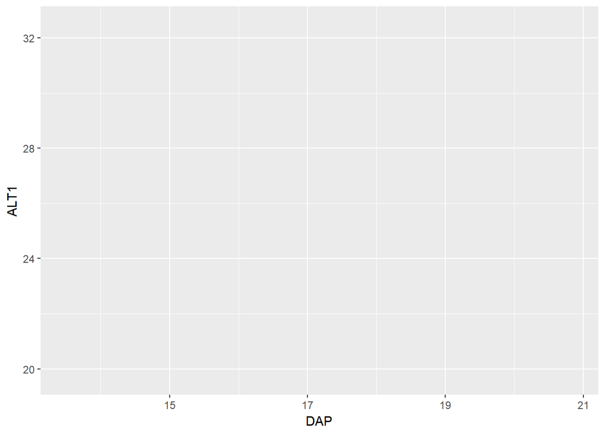

```r
a <- ggplot(dados_g, aes(x = DAP, y = ALT1))
a
```

depois adiciona-se outras camadas

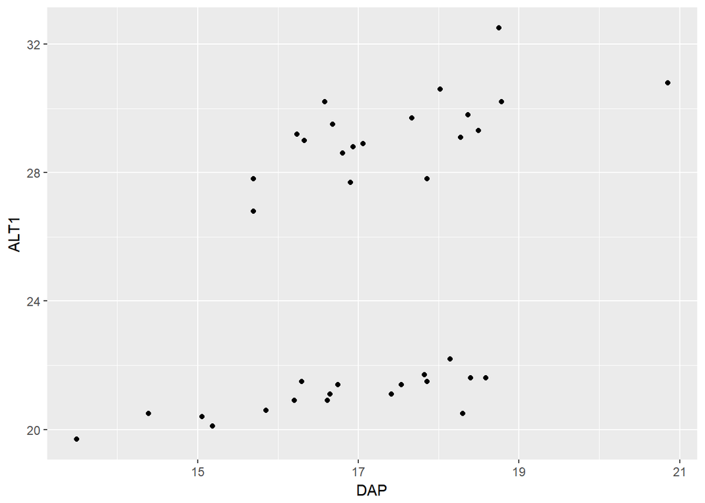

```r
a + geom_point()
```

tamanho personalizado

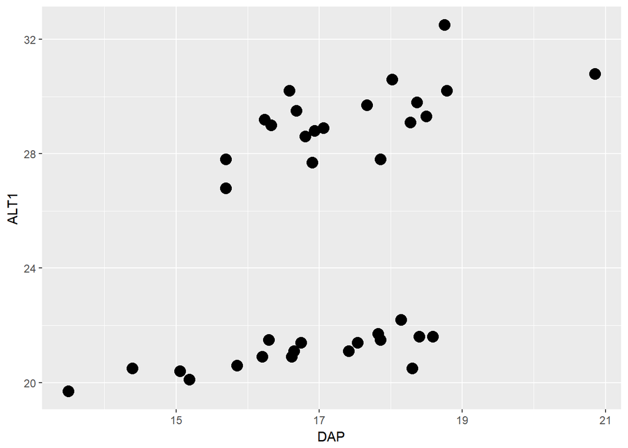

```r
a + geom_point( size = 4)
```

Cor personalizada

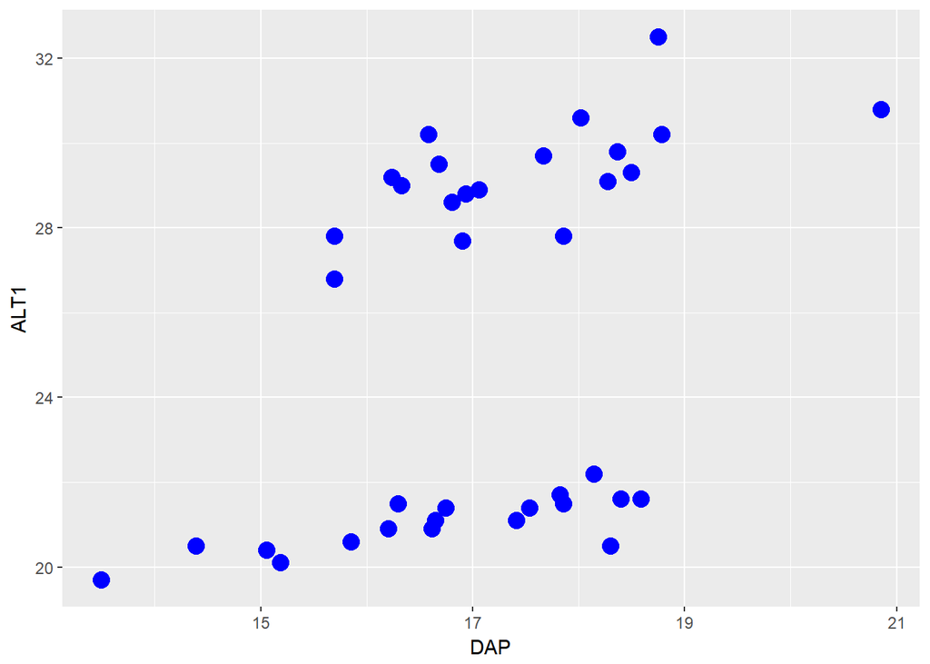

```r
a + geom_point(size = 4, color = "blue")
```

Transparencia nos pontos

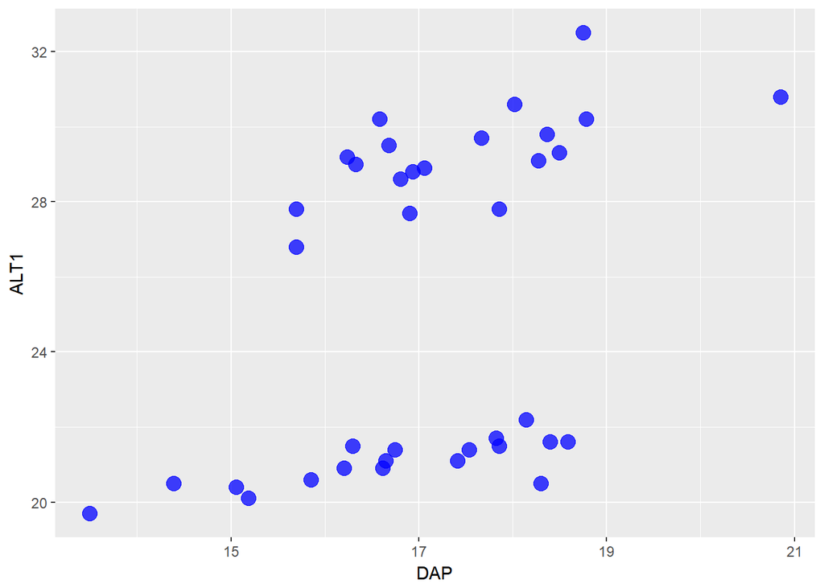

```r
a + geom_point(size = 4, color = "blue", alpha = .75)
```

pode-se preencher os dados com uma variavel classificatoria

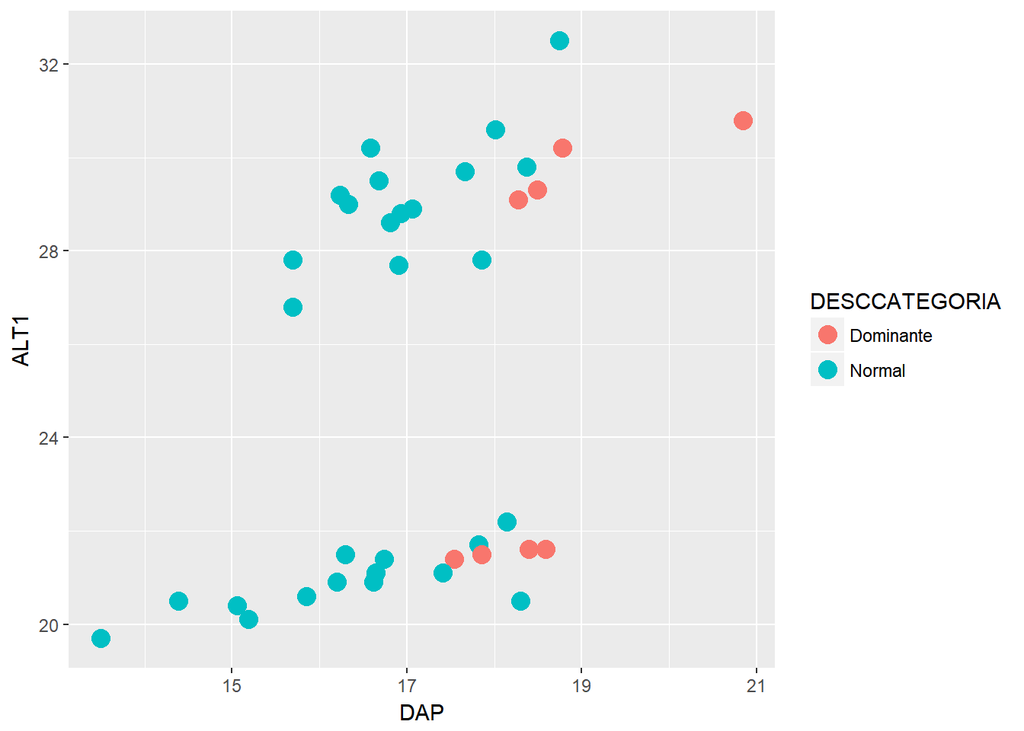

```r
a + geom_point(size = 4, aes(color=DESCCATEGORIA))
```

titulo personalizado

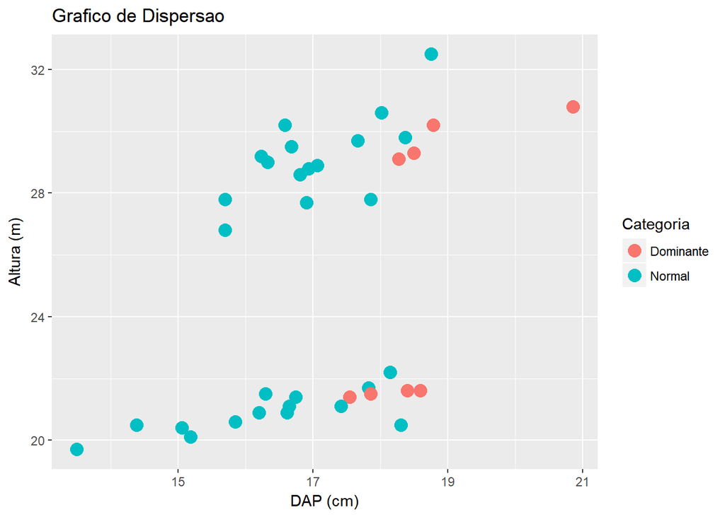

```r
a + geom_point(size = 4, aes(color=DESCCATEGORIA)) +
  labs(x="DAP (cm)", y="Altura (m)", colour = "Categoria", title = "Grafico de Dispersao")
```

Tamanho e fonte personalizado

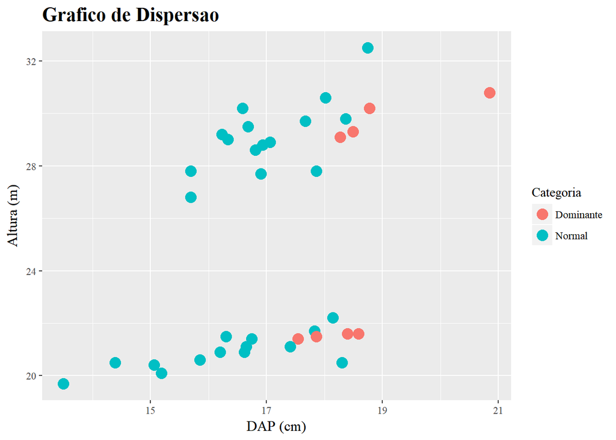

```r
a + geom_point(size = 4, aes(color=DESCCATEGORIA)) +
  labs(x="DAP (cm)", y="Altura (m)", colour = "Categoria", title = "Grafico de Dispersao") +
theme_gray(base_family = "serif") +
theme(
  plot.title=element_text(size = 16, face="bold", vjust = 0.9),
  axis.title=element_text(size = 12))
```

Limites do eixo y personalizado

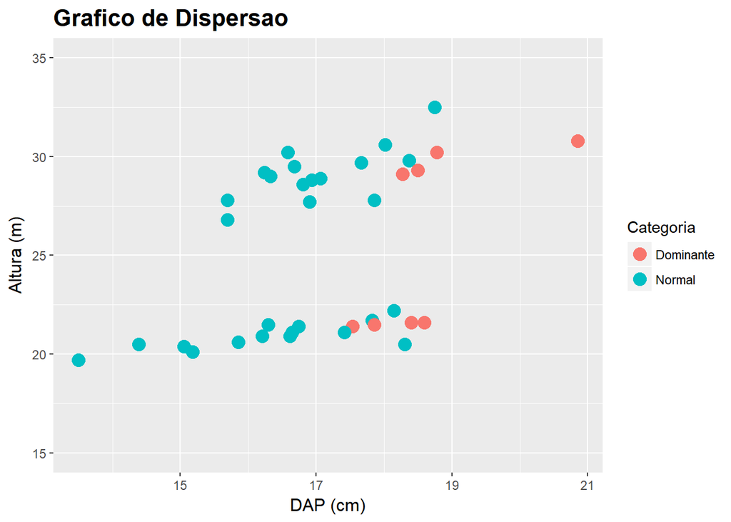

```r
a + geom_point(size = 4, aes(color=DESCCATEGORIA)) +
  labs(x="DAP (cm)", y="Altura (m)", colour = "Categoria", title = "Grafico de Dispersao") +
  theme(
    plot.title=element_text(size = 16, face="bold", vjust = 0.9),
    axis.title=element_text(size = 12)) +
  coord_cartesian(ylim = c(15,35))
```

linha de tendencia

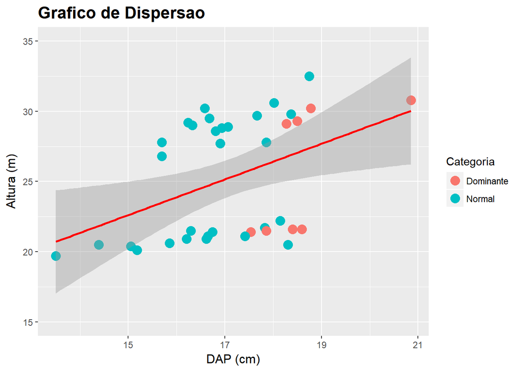

```r
a  + geom_point(size = 4, aes(color=DESCCATEGORIA)) +
  labs(x="DAP (cm)", y="Altura (m)", colour = "Categoria", title = "Grafico de Dispersao") +
  theme(
    plot.title=element_text(size = 16, face="bold", vjust = 0.9),
    axis.title=element_text(size = 12)) +
  coord_cartesian(ylim = c(15,35)) +
  geom_smooth(method = "lm", color = "red")
```

linha de tendencia sem intervalo de confiança

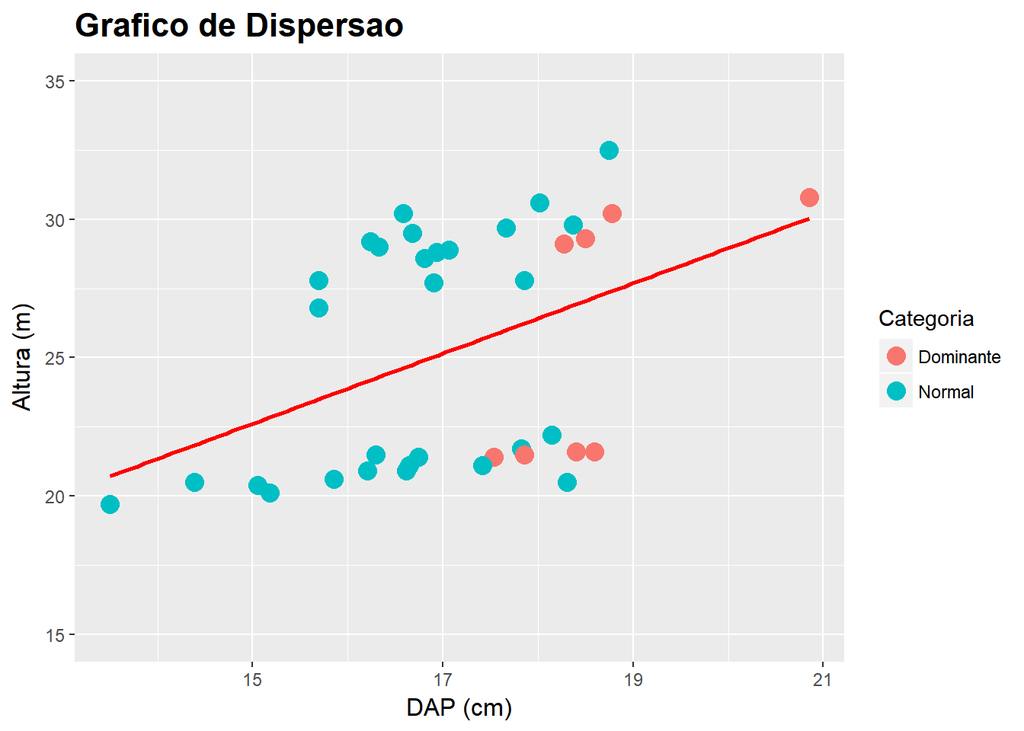

```r
a  + geom_point(size = 4, aes(color=DESCCATEGORIA)) +
  labs(x="DAP (cm)", y="Altura (m)", colour = "Categoria", title = "Grafico de Dispersao") +
  theme(
    plot.title=element_text(size = 16, face="bold", vjust = 0.9),
    axis.title=element_text(size = 12)) +
  coord_cartesian(ylim = c(15,35)) +
  geom_smooth(method = "lm", color = "red", se=FALSE)
```

tema diferente

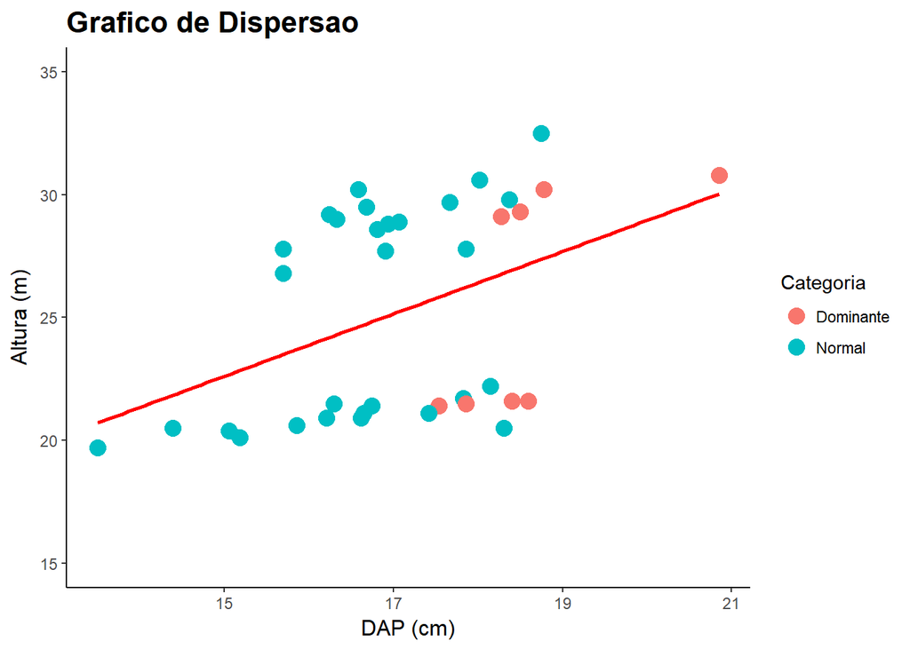

```r
a  + geom_point(size = 4, aes(color=DESCCATEGORIA)) +
  labs(x="DAP (cm)", y="Altura (m)", colour = "Categoria", title = "Grafico de Dispersao") +
  theme_classic() +
  theme(
    plot.title=element_text(size = 16, face="bold", vjust = 0.9),
    axis.title=element_text(size = 12)) +
  coord_cartesian(ylim = c(15,35)) +
  geom_smooth(method = "lm", color = "red", se=FALSE)
```

Fonte times new roman

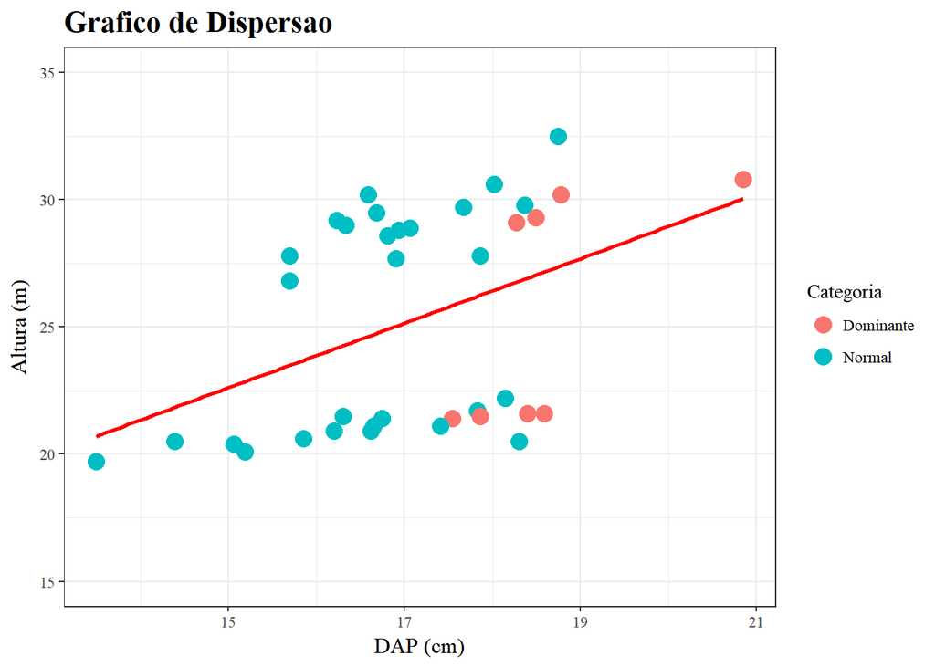

```r
a  + geom_point(size = 4, aes(color=DESCCATEGORIA)) +
    labs(x="DAP (cm)", y="Altura (m)", colour = "Categoria", title = "Grafico de Dispersao") +
    theme_bw(base_family = "serif") +
    theme(
      plot.title=element_text(size = 16, face="bold", vjust = 0.9),
      axis.title=element_text(size = 12)) +
    coord_cartesian(ylim = c(15,35)) +
    geom_smooth(method = "lm", color = "red", se=FALSE)
```

Pode-se utilizar subsetting com uma variavel categorica

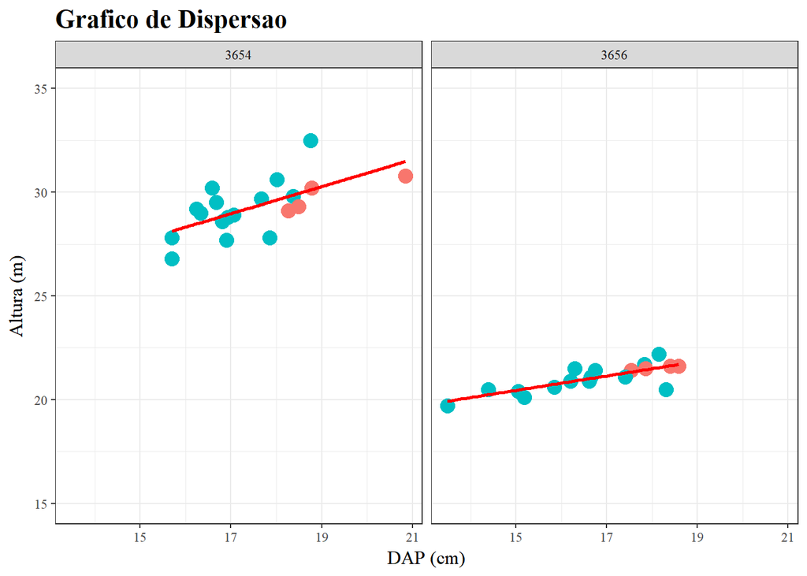

```r
a + geom_point(size = 4, aes(color=DESCCATEGORIA), show.legend = F) +
  labs(x="DAP (cm)", y="Altura (m)", colour = "Categoria", title = "Grafico de Dispersao") +
  theme_bw(base_family = "serif") +
  theme(
    plot.title=element_text(size = 16, face="bold", vjust = 0.9),
    axis.title=element_text(size = 12)) +
  coord_cartesian(ylim = c(15,35)) +
  geom_smooth(method = "lm", color = "red", se=FALSE) +
  facet_grid(.~CODTALHAO)
```

Grafico em escala de cinza para variável discreta

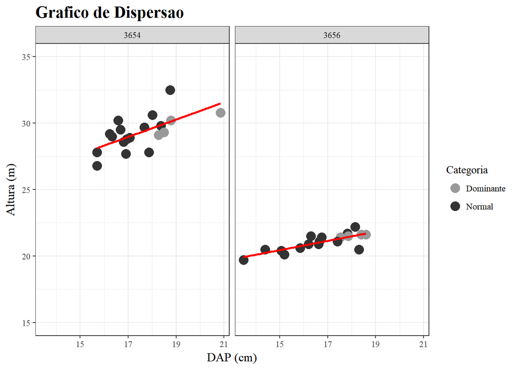

```r
a + geom_point(size = 4, aes(color=DESCCATEGORIA)) +
  labs(x="DAP (cm)", y="Altura (m)", colour = "Categoria", title = "Grafico de Dispersao") +
  theme_bw(base_family = "serif") +
  theme(
    plot.title=element_text(size = 16, face="bold", vjust = 0.9),
    axis.title=element_text(size = 12)) +
  coord_cartesian(ylim = c(15,35)) +
  geom_smooth(method = "lm", color = "red", se=FALSE) +
  facet_grid(.~CODTALHAO) +
  scale_colour_grey(start = 0.6, end = 0.2)
```

Grafico em escala de cinza para variável contínua

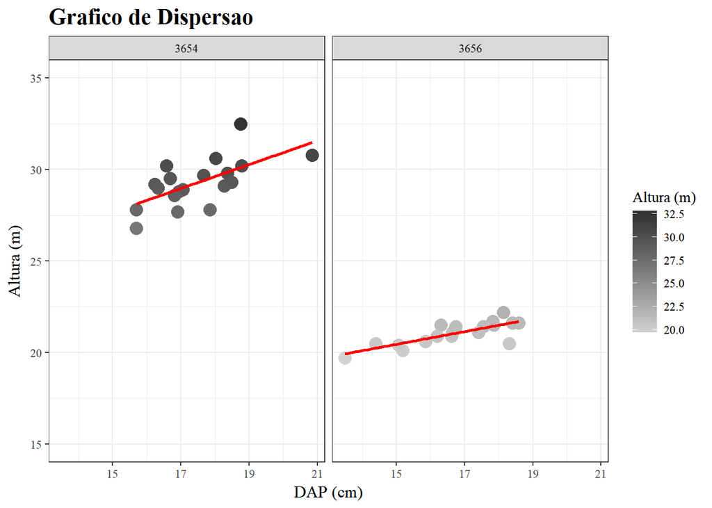

```r
a + geom_point(size = 4, aes(color=ALT1)) +
  labs(x="DAP (cm)", y="Altura (m)", colour = "Altura (m)", title = "Grafico de Dispersao") +
  theme_bw(base_family = "serif") +
  theme(
    plot.title=element_text(size = 16, face="bold", vjust = 0.9),
    axis.title=element_text(size = 12)) +
  coord_cartesian(ylim = c(15,35)) +
  geom_smooth(method = "lm", color = "red", se=FALSE) +
  facet_grid(.~CODTALHAO) +
  scale_colour_gradient(low = "light gray",high = "gray20")
```

Mais customizações em theme

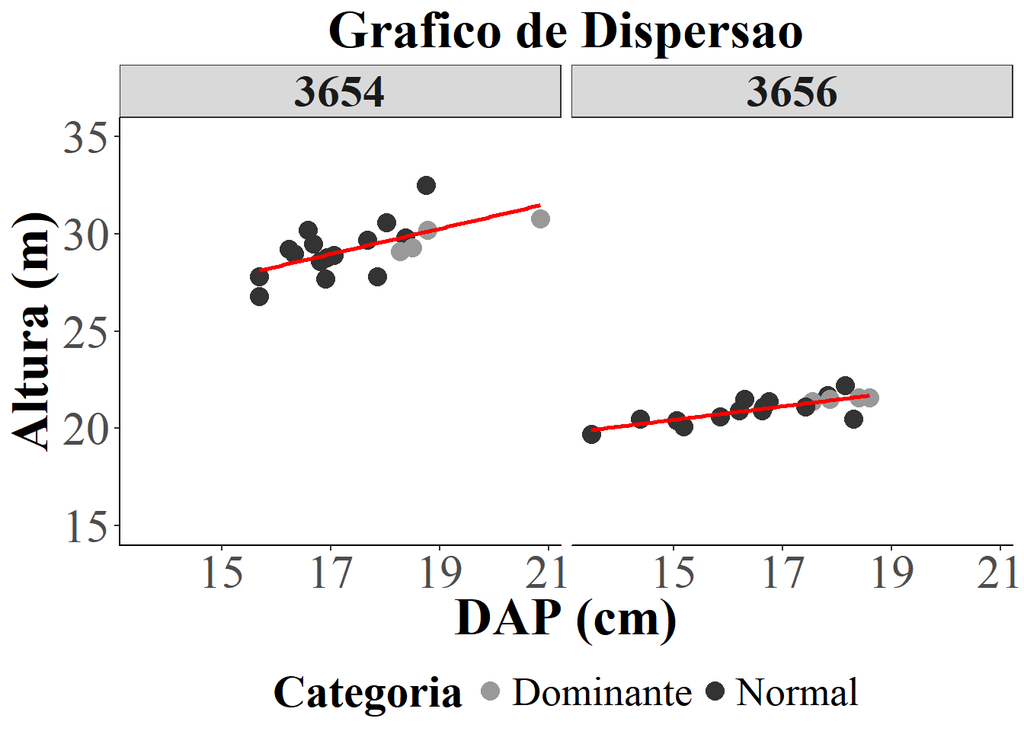

```r
a + geom_point(size = 4, aes(color=DESCCATEGORIA)) +
  labs(x="DAP (cm)", y="Altura (m)", colour = "Categoria", title = "Grafico de Dispersao") +
  theme_bw(base_family = "serif") +
  theme(
    legend.position = "bottom",
    panel.grid.major = element_blank(),
    panel.grid.minor = element_blank(),
    panel.border = element_blank(),
    plot.title = element_text(size = 26, face = "bold", hjust = 0.5),
    axis.title = element_text(size = 26, face = "bold"),
    axis.text = element_text(size = 23),
    axis.line.x = element_line(color = "black"),
    axis.line.y = element_line(color = "black"),
    strip.text.x = element_text(size = 22,face = "bold"),
    legend.text = element_text(size = 20),
    legend.title = element_text(size = 22, face="bold") ) +
  coord_cartesian(ylim = c(15,35)) +
  geom_smooth(method = "lm", color = "red", se=FALSE) +
  facet_grid(.~CODTALHAO) +
  scale_colour_grey(start = 0.6, end = 0.2)
```

## 10.2) Histogramas

Histograma para o DAP

```r
b <- ggplot(dados_g, aes(x = DAP, y=..density..)) +
  theme_bw(base_family = "serif") +
  theme(
    legend.position = "bottom",
    panel.grid.major = element_blank(),
    panel.grid.minor = element_blank(),
    panel.border = element_blank(),
    plot.title = element_text(size = 26, face = "bold", hjust = 0.5),
    axis.title = element_text(size = 26, face = "bold"),
    axis.text = element_text(size = 23),
    axis.line.x = element_line(color = "black"),
    axis.line.y = element_line(color = "black"),
    strip.text.x = element_text(size = 22,face = "bold"),
    legend.text = element_text(size = 20),
    legend.title = element_text(size = 22, face="bold") ) +
  scale_colour_grey(start = 0.6, end = 0.2) +
  scale_fill_grey(start = 0.6, end = 0.2)
```

para se criar um histograma basta alterar o argumento geom_

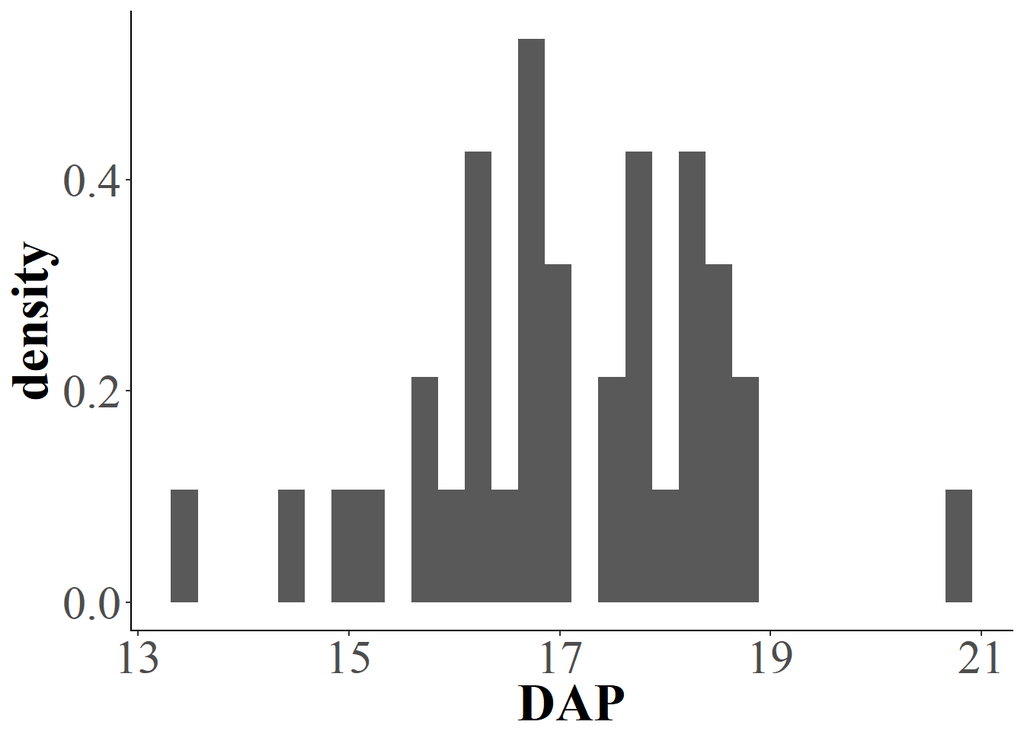

```r
b + geom_histogram()
```

frequencia ao inves de densidade

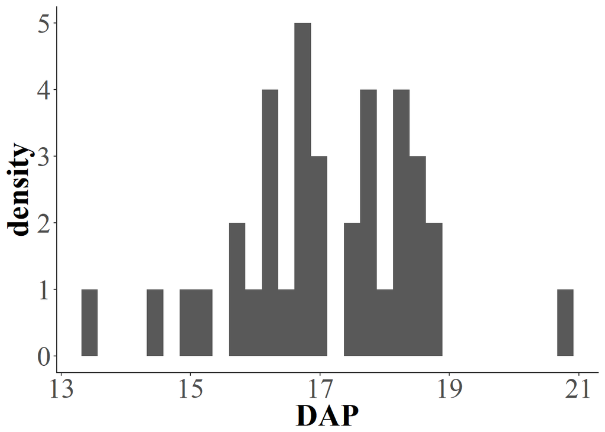

```r
b + geom_histogram(aes(y=..count..))
```

Largura das colunas

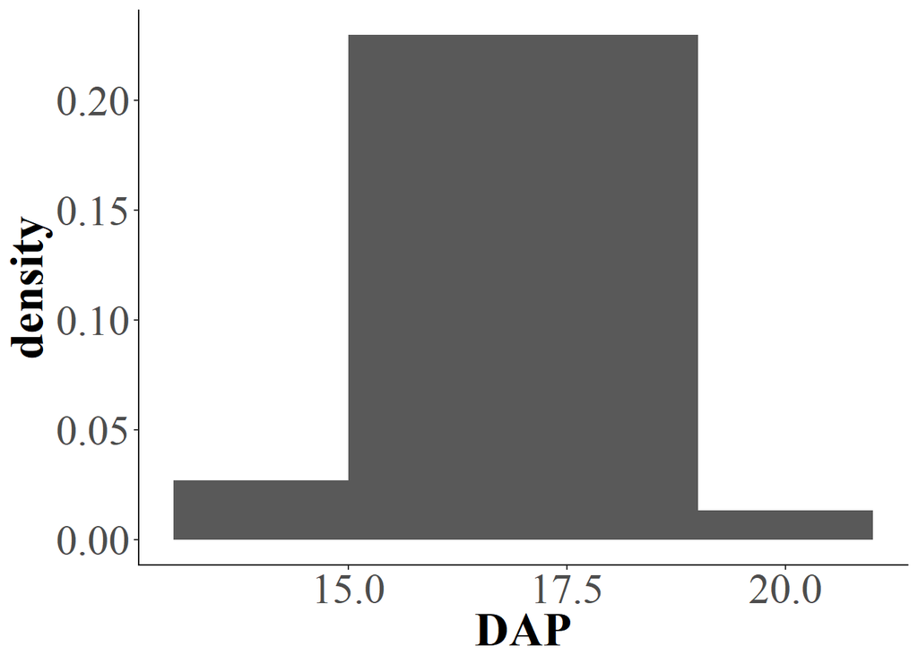

```r
b + geom_histogram(binwidth = 2)
```

cor personalizada

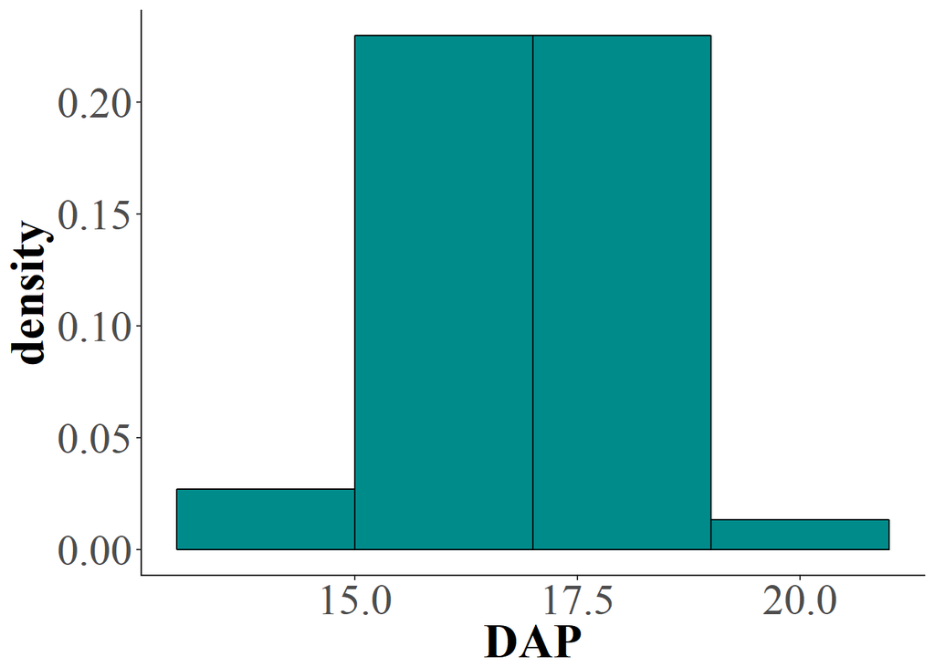

```r
b + geom_histogram(binwidth = 2, fill = "cyan4", color = "black")
```

Preenchimento personalizado

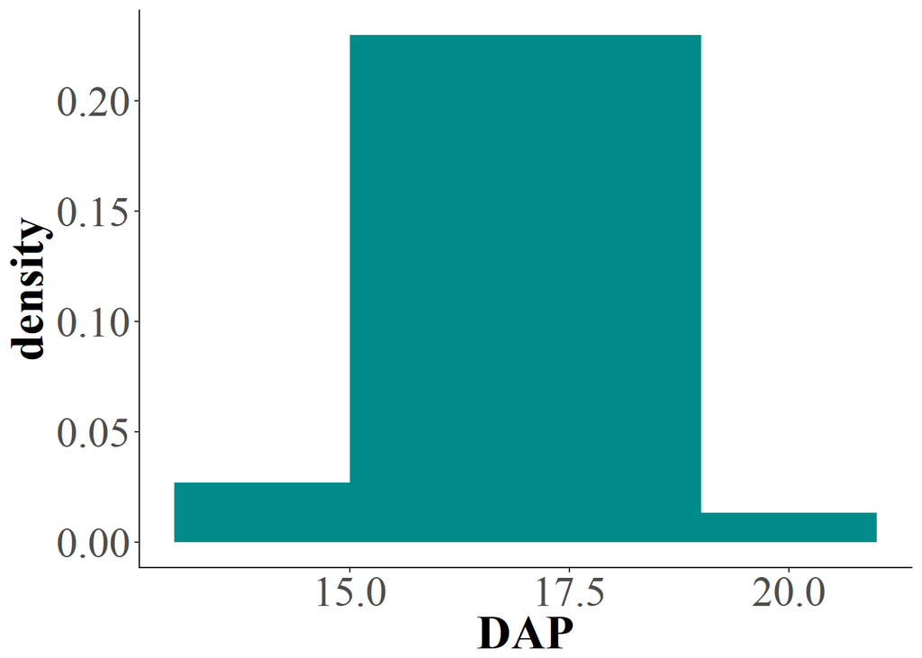

```r
b + geom_histogram(binwidth = 2, fill = "cyan4")
```

Largura das colunas

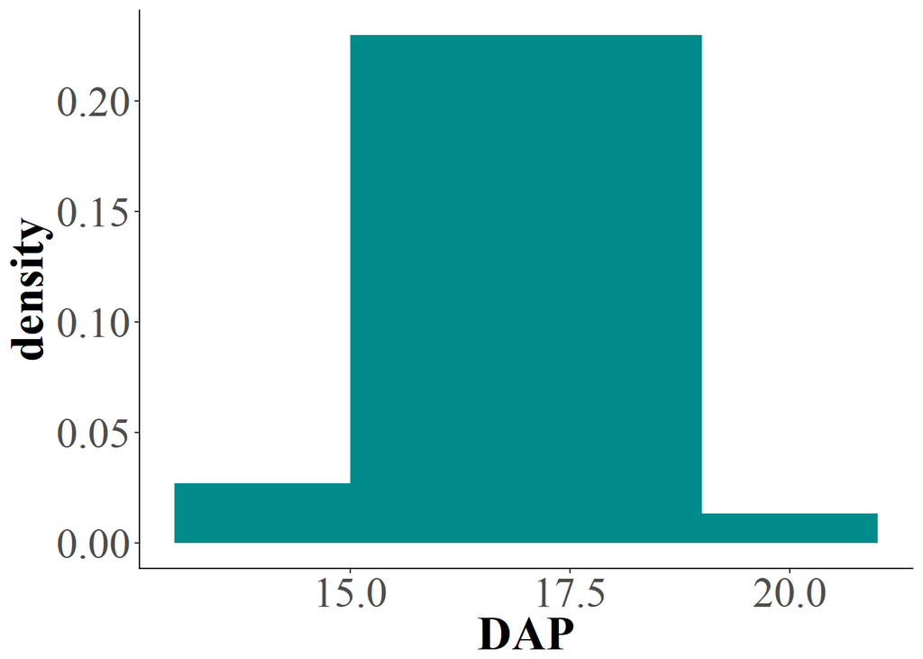

```r
b + geom_histogram(binwidth = 2, fill = "cyan4")
```

pode-se preencher os dados com uma variavel classificatoria

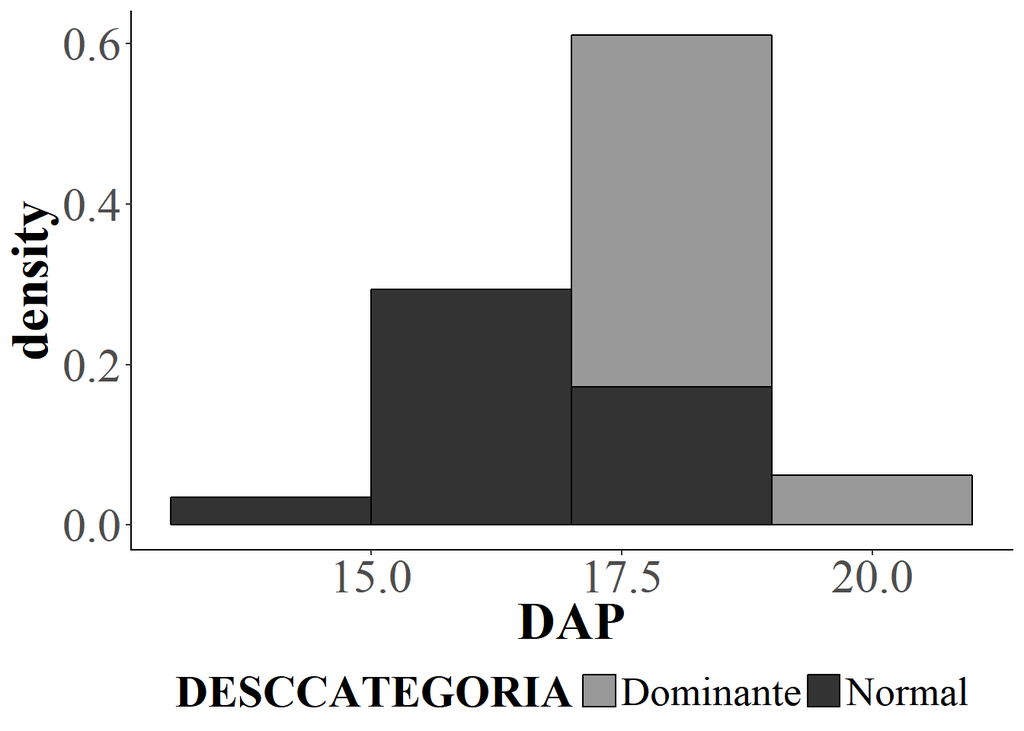

```r
b + geom_histogram(binwidth = 2, aes(fill = DESCCATEGORIA), color = "black")
```

sem legenda

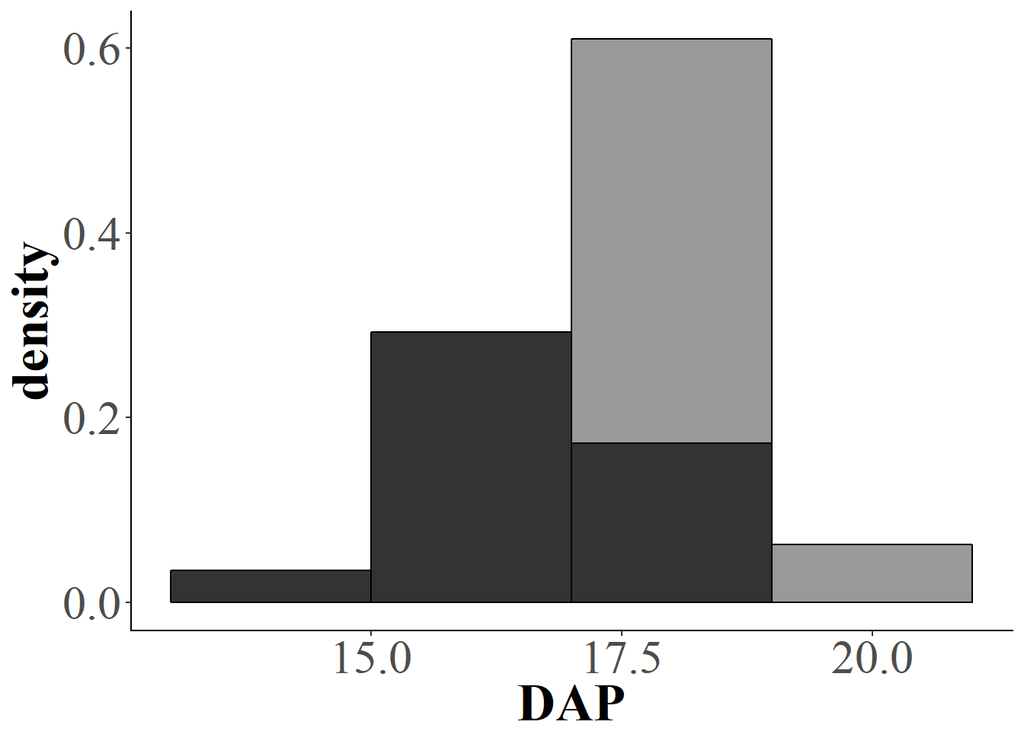

```r
b + geom_histogram(binwidth = 2, aes(fill = DESCCATEGORIA), color = "black", show.legend = FALSE)
```

TItulo

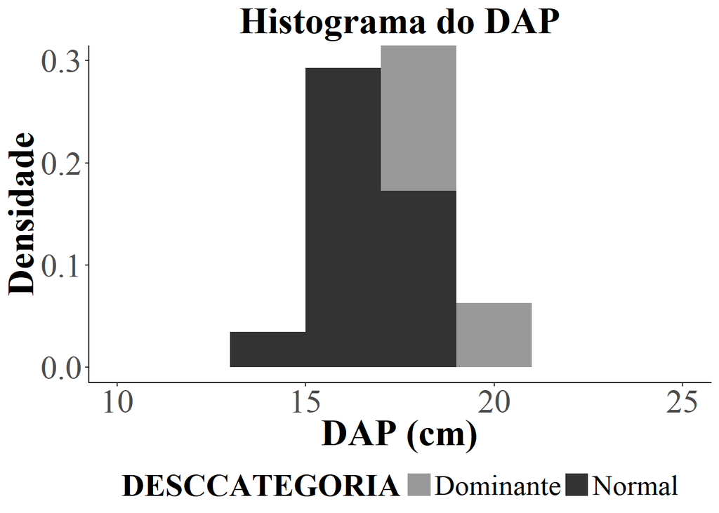

```r
b + geom_histogram(binwidth = 2, aes(fill = DESCCATEGORIA)) +
  labs(x = "DAP (cm)", y = "Densidade", title = "Histograma do DAP") +
  coord_cartesian(xlim = c(10,25), ylim = c(0, .3))
```

Curva de densidade

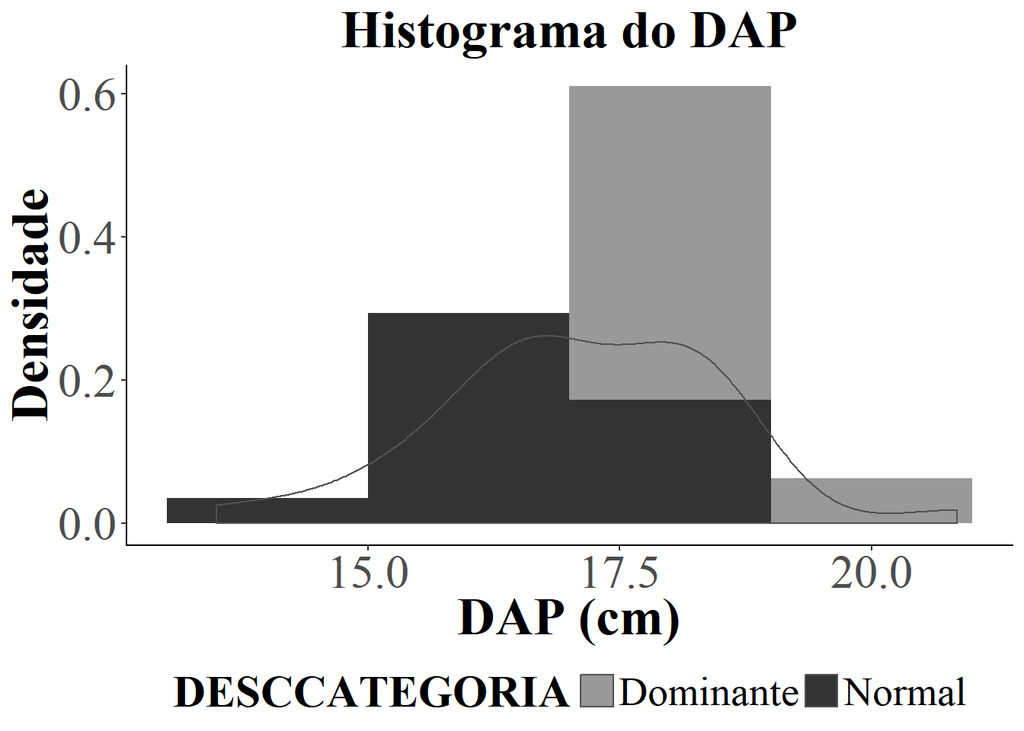

```r
b + geom_histogram(binwidth = 2, aes(fill = DESCCATEGORIA)) +
  labs(x = "DAP (cm)", y = "Densidade", title = "Histograma do DAP") +
  geom_density(color = "grey32")
```